# Zadanie domowe - EDA Danych dotyczących Titanica

- Twoim zadaniem jest wykonanie analizy danych zawartych w załączonym pliku CSV (`26__titanic.csv`).
- Plik znajduje się pod video. Pamiętaj, żeby wrzucić plik do tego samego folderu, w którym znajduje się ten notebook.
- Wykorzystaj nowo nabytą wiedzę z biblioteki `Pandas`
- Jeżeli jest taka konieczność posiłkuj się [code explainerem](https://codeexplainer.imprv.ai/) lub / i [data chatterem](https://datachatter.imprv.ai/) (który również te dane ma dostępne).
- Prześlij na discordzie notebook z rozwiązaniem (`#modul-4-zad2`)
- Pamiętaj:
1. Nie spiesz się
2. Potraktuj zadanie domowe jak prawdziwy projekt
3. Dodawaj opisy, obserwacje, wnioski
4. Dodaj wizualizacje
5. Dodaj konkluzję i wnioski końcowe

Powodzenia!!! I mega zabawy!

## O Danych

Dane o pasażerach Titanica

Zbiór danych zawiera informacje o pasażerach RMS Titanic, który zatonął 15 kwietnia 1912 roku po zderzeniu z górą lodową. Dane obejmują takie atrybuty jak klasa podróży, wiek, płeć, liczba rodzeństwa/małżonków na pokładzie, liczba rodziców/dzieci na pokładzie, cena biletu oraz miejsce zaokrętowania.

Zbiór zawiera także informację o tym, czy pasażer przeżył katastrofę.

Titanic przewoził ponad 2,200 osób, z czego ponad 1,500 zginęło, co czyni tę katastrofę jedną z najbardziej tragicznych w historii morskiej.

Kolumny:

- **pclass** - Klasa biletu
- **survived** - Czy pasażer przeżył katastrofę
- **name** - Imię i nazwisko pasażera
- **sex** - Płeć pasażera
- **age** - Wiek pasażera
- **sibsp** - Liczba rodzeństwa/małżonków na pokładzie
- **parch** - Liczba rodziców/dzieci na pokładzie
- **ticket** - Numer biletu
- **fare** - Cena biletu
- **cabin** - Numer kabiny
- **embarked** - Port, w którym pasażer wszedł na pokład (C = Cherbourg, Q = Queenstown, S = Southampton)
- **boat** - Numer łodzi ratunkowej
- **body** - Numer ciała (jeśli pasażer nie przeżył i ciało zostało odnalezione)
- **home.dest** - Miejsce docelowe

```python
import pandas as pd
import numpy as np #
import matplotlib.pyplot as plt #przyda się już przy wykresie kołowym
import seaborn as sns #przyda się przy rysowaniu mapy korelacji
import statsmodels.api as sm # potrzebne eksperymetnów (do modelu regresji)
from IPython.display import display, HTML
```

```
                O charakterze naszych danych....
```

Możemy przyjąć na razie, założyć że na nasze dane będziemy patrzeć pod kątem ludzi oraz ich związkach ze sobą, ze statkiem, i hisorią jaka ich spotkała. **Ludzie - dane o ludziach:**

- Imię i nazwisko/ Płeć / WIek /
- liczba rodzeństwa/małżonków na pokładzie,
- liczba rodziców/dzieci na pokładzie

**Ludzie - statek:**

- klasa biletu,
- numer biletu
- cena biletu
- numer kabiny

**Ludzie - trasa statku:**

- Port, w którym pasażer wszedł na pokład (C = Cherbourg, Q = Queenstown, S = Southampton)

**Ludzie - zdarzenia:**

- Czy pasażer przeżył? /
- Numer łodzi ratunkowej
- Numer ciała (jeśli pasażer nie przeżył i ciało zostało odnalezione)
- Miejsce docelowe

[figure not shown]

```
                     Ludzie na tle Titanica
```

[figure not shown]

```
                       Trasa Tytanica
```

RMS[a] Titanic (wym. [taɪˈtænɪk]) – brytyjski transatlantyk typu Olympic należący do towarzystwa żeglugowego White Star Line, zbudowany w stoczni Harland and Wolff w Belfaście.

Niespełna rok po zwodowaniu, w nocy z 14 na 15 kwietnia 1912 roku, podczas dziewiczego rejsu na trasie Southampton – Cherbourg – Queenstown – Nowy Jork, otarł się o górę lodową i zatonął. Jego katastrofa spowodowała znaczącą nowelizację zasad bezpieczeństwa morskiego, np. wprowadzenie stałego nadzoru gór lodowych na północnym Atlantyku. [źródło - wikipedia]

### EDA Danych dotyczących Titanica

- Ogólny przegląd danych
- Analiza brakujących wartości
- Analiza pojedyńczych zmiennych
- Transformacja danych /naprawa błędów/
- Analiza relacji między zmiennymi
- Analiza wartości odstających

```python
df = pd.read_csv('26__titanic.csv', sep=",")
pd.options.display.max_columns= None #Żeby móc zobaczyć cały zakres df
df
```

|  | pclass | survived | name | sex | age | sibsp | parch | ticket | fare | cabin | embarked | boat | body | home.dest |
| --- | --- | --- | --- | --- | --- | --- | --- | --- | --- | --- | --- | --- | --- | --- |
| 0 | 1.0 | 1.0 | Allen, Miss. Elisabeth Walton | female | 29.0000 | 0.0 | 0.0 | 24160 | 211.3375 | B5 | S | 2 | NaN | St Louis, MO |
| 1 | 1.0 | 1.0 | Allison, Master. Hudson Trevor | male | 0.9167 | 1.0 | 2.0 | 113781 | 151.5500 | C22 C26 | S | 11 | NaN | Montreal, PQ / Chesterville, ON |
| 2 | 1.0 | 0.0 | Allison, Miss. Helen Loraine | female | 2.0000 | 1.0 | 2.0 | 113781 | 151.5500 | C22 C26 | S | NaN | NaN | Montreal, PQ / Chesterville, ON |
| 3 | 1.0 | 0.0 | Allison, Mr. Hudson Joshua Creighton | male | 30.0000 | 1.0 | 2.0 | 113781 | 151.5500 | C22 C26 | S | NaN | 135.0 | Montreal, PQ / Chesterville, ON |
| 4 | 1.0 | 0.0 | Allison, Mrs. Hudson J C (Bessie Waldo Daniels) | female | 25.0000 | 1.0 | 2.0 | 113781 | 151.5500 | C22 C26 | S | NaN | NaN | Montreal, PQ / Chesterville, ON |
| ... | ... | ... | ... | ... | ... | ... | ... | ... | ... | ... | ... | ... | ... | ... |
| 1305 | 3.0 | 0.0 | Zabour, Miss. Thamine | female | NaN | 1.0 | 0.0 | 2665 | 14.4542 | NaN | C | NaN | NaN | NaN |
| 1306 | 3.0 | 0.0 | Zakarian, Mr. Mapriededer | male | 26.5000 | 0.0 | 0.0 | 2656 | 7.2250 | NaN | C | NaN | 304.0 | NaN |
| 1307 | 3.0 | 0.0 | Zakarian, Mr. Ortin | male | 27.0000 | 0.0 | 0.0 | 2670 | 7.2250 | NaN | C | NaN | NaN | NaN |
| 1308 | 3.0 | 0.0 | Zimmerman, Mr. Leo | male | 29.0000 | 0.0 | 0.0 | 315082 | 7.8750 | NaN | S | NaN | NaN | NaN |
| 1309 | NaN | NaN | NaN | NaN | NaN | NaN | NaN | NaN | NaN | NaN | NaN | NaN | NaN | NaN |

1310 rows × 14 columns

W przykładowym wycinku naszej bazy danych widać anglojęzyczne pochodzenie danch, nazw kolumn jak i słownych zawartości wierszy (male, female). Rzuca się w oczy brak danch, których ilość trzeba będzie ustalić i z którymi trzeba będzie coś zrobić. Format danych, mógłby być lepiej dopasowany do rodzaju danch (kolumny pclass, survived, age, sibsp, parch, fare, body) mają niepotrzebnie za dużo miejsc po przecinku. W tym wycinku są tylko klasy biletów 1 i 3. Dominuje tu przeważająca liczba osób, które nie przeżyły katastrofę. Interesująco wyglądają natomiast angielskie zwroty grzecznościowe przy nazwiskach - Miss(Panna), Master(coś jak "młody człowieku", coś w rodzaju kawalera - choć nie ma to odpowiednika w języku polskim), Mr.(Mister - Pan), Mrs. (Mistress - Pani). Do tego różną długość mają numery biletu, a miejsce docelowe składa np. z miejscowości i stanu w którym ta miejscowość się znajduje, do tego czasami występują aż trzy miejscowości (jakby było wpisane miejsce początkowe, pośrednie i docelowe). Dane wyglądają jakby czekały na uporządkowanie. A więc do dzieła...

Czy dane zawierają jakieś osoby, które pracowały na statku ? Sprawdzimy kilka kluczowych postaci czy występują w bazie danch ?

- Edward Smith - Kapitan statku.
- Henry Tingle Wilde - Pierwszy oficer.
- Charles Herbert Lightoller - Drugi oficer, który przeżył katastrofę.
- William McMaster Murdoch - Pierwszy oficer, który zginął podczas katastrofy.
- Thomas Andrews - Główny projektant Titanica, który był na pokładzie podczas rejsu.
- J. Bruce Ismay - Prezydent White Star Line, który również był pasażerem.
- Frederick Fleet - Lookout, który jako pierwszy zauważył górę lodową.

```python
# Filter the dataframe for rows containing the specified last names
last_names = ["Smith", "Tingle", "Wilde", "Lightoller", "McMaster", "Murdoch", "Andrews", "Ismay", "Fleet"]
filtered_df = df[df['Imię i nazwisko'].str.contains('|'.join(last_names), case=False, na=False)]
# Tworzymy HTML z tabelą
html_table = filtered_df.to_html(index=False)

# Wyświetlamy tabelę z paskiem przewijania
display(HTML(f'<div style="overflow-x: auto;">{html_table}</div>'))
```

[output not shown]

- Thomas Andrews,
- J. Bruce Ismay , byli na liście pasażerów Tytanika ale byli na statku bardziej jako goście honorowi, którzy do czasu katastrofy nie wykonywali żadnej pracy na statku. Możemy przez to założyć, że pracownicy Tytanika nie są ujęci w naszej bazie danych.

```python
df.columns
```

```
Index(['pclass', 'survived', 'name', 'sex', 'age', 'sibsp', 'parch', 'ticket',
       'fare', 'cabin', 'embarked', 'boat', 'body', 'home.dest'],
      dtype='object')
```

Wyświetlamy nazwy wszystkich kolumn w naszym df

```python
df = df.rename(columns={'pclass':'Klasa biletu','survived':'Przeżył ?',
                        'name':'Imię i nazwisko','sex':'Płeć','age':'Wiek',
                        'sibsp':'Ilość-rodzeństwo/małżonek','parch':'Ilość-rodziców/dzieci',
                        'ticket':'Numer biletu','fare':'Cena biletu','cabin':'Numer kabiny',
                        'embarked':'Port wejścia pasażera','boat':'Nr łodzi ratunkowej',
                        'body':'Numer ciała','home.dest':'Miejsce docelowe'})
```

Skoro naszym odbiorcą jest klient z Polski, to zmieniamy wszystkie nazwy na język polski. Zaczynamy od zmiany nazwy kolumn.

```python
df.columns
```

```
Index(['Klasa biletu', 'Przeżył ?', 'Imię i nazwisko', 'Płeć', 'Wiek',
       'Ilość-rodzeństwo/małżonek', 'Ilość-rodziców/dzieci', 'Numer biletu',
       'Cena biletu', 'Numer kabiny', 'Port wejścia pasażera',
       'Nr łodzi ratunkowej', 'Numer ciała', 'Miejsce docelowe'],
      dtype='object')
```

```
                Nazwy kolumn po zmianie na język polski
```

```python
df
```

|  | Klasa biletu | Przeżył ? | Imię i nazwisko | Płeć | Wiek | Ilość-rodzeństwo/małżonek | Ilość-rodziców/dzieci | Numer biletu | Cena biletu | Numer kabiny | Port wejścia pasażera | Nr łodzi ratunkowej | Numer ciała | Miejsce docelowe |
| --- | --- | --- | --- | --- | --- | --- | --- | --- | --- | --- | --- | --- | --- | --- |
| 0 | 1.0 | 1.0 | Allen, Miss. Elisabeth Walton | female | 29.0000 | 0.0 | 0.0 | 24160 | 211.3375 | B5 | S | 2 | NaN | St Louis, MO |
| 1 | 1.0 | 1.0 | Allison, Master. Hudson Trevor | male | 0.9167 | 1.0 | 2.0 | 113781 | 151.5500 | C22 C26 | S | 11 | NaN | Montreal, PQ / Chesterville, ON |
| 2 | 1.0 | 0.0 | Allison, Miss. Helen Loraine | female | 2.0000 | 1.0 | 2.0 | 113781 | 151.5500 | C22 C26 | S | NaN | NaN | Montreal, PQ / Chesterville, ON |
| 3 | 1.0 | 0.0 | Allison, Mr. Hudson Joshua Creighton | male | 30.0000 | 1.0 | 2.0 | 113781 | 151.5500 | C22 C26 | S | NaN | 135.0 | Montreal, PQ / Chesterville, ON |
| 4 | 1.0 | 0.0 | Allison, Mrs. Hudson J C (Bessie Waldo Daniels) | female | 25.0000 | 1.0 | 2.0 | 113781 | 151.5500 | C22 C26 | S | NaN | NaN | Montreal, PQ / Chesterville, ON |
| ... | ... | ... | ... | ... | ... | ... | ... | ... | ... | ... | ... | ... | ... | ... |
| 1305 | 3.0 | 0.0 | Zabour, Miss. Thamine | female | NaN | 1.0 | 0.0 | 2665 | 14.4542 | NaN | C | NaN | NaN | NaN |
| 1306 | 3.0 | 0.0 | Zakarian, Mr. Mapriededer | male | 26.5000 | 0.0 | 0.0 | 2656 | 7.2250 | NaN | C | NaN | 304.0 | NaN |
| 1307 | 3.0 | 0.0 | Zakarian, Mr. Ortin | male | 27.0000 | 0.0 | 0.0 | 2670 | 7.2250 | NaN | C | NaN | NaN | NaN |
| 1308 | 3.0 | 0.0 | Zimmerman, Mr. Leo | male | 29.0000 | 0.0 | 0.0 | 315082 | 7.8750 | NaN | S | NaN | NaN | NaN |
| 1309 | NaN | NaN | NaN | NaN | NaN | NaN | NaN | NaN | NaN | NaN | NaN | NaN | NaN | NaN |

1310 rows × 14 columns

```python
# df.describe() #Wyświetlamy podsumowanie statystyk
# Dobrze by było zaokrąglić wynik do dwóch miejsc po przecinku.
# print(df.describe().round(2)) # Ta linijka załatwia sprawę
statistics = df.describe(include='all').T  # Dodaj .T na końcu, aby transponować DataFrame

# Wyświetl DataFrame
print(statistics)
```

```
                            count unique                   top freq  \
Klasa biletu               1309.0    NaN                   NaN  NaN
Przeżył ?                  1309.0    NaN                   NaN  NaN
Imię i nazwisko              1309   1307  Connolly, Miss. Kate    2
Płeć                         1309      2                  male  843
Wiek                       1046.0    NaN                   NaN  NaN
Ilość-rodzeństwo/małżonek  1309.0    NaN                   NaN  NaN
Ilość-rodziców/dzieci      1309.0    NaN                   NaN  NaN
Numer biletu                 1309    929              CA. 2343   11
Cena biletu                1308.0    NaN                   NaN  NaN
Numer kabiny                  295    186           C23 C25 C27    6
Port wejścia pasażera        1307      3                     S  914
Nr łodzi ratunkowej           486     27                    13   39
Numer ciała                 121.0    NaN                   NaN  NaN
Miejsce docelowe              745    369          New York, NY   64

                                 mean        std     min     25%      50%  \
Klasa biletu                 2.294882   0.837836     1.0     2.0      3.0
Przeżył ?                    0.381971   0.486055     0.0     0.0      0.0
Imię i nazwisko                   NaN        NaN     NaN     NaN      NaN
Płeć                              NaN        NaN     NaN     NaN      NaN
Wiek                        29.881135    14.4135  0.1667    21.0     28.0
Ilość-rodzeństwo/małżonek    0.498854   1.041658     0.0     0.0      0.0
Ilość-rodziców/dzieci        0.385027    0.86556     0.0     0.0      0.0
Numer biletu                      NaN        NaN     NaN     NaN      NaN
Cena biletu                 33.295479  51.758668     0.0  7.8958  14.4542
Numer kabiny                      NaN        NaN     NaN     NaN      NaN
Port wejścia pasażera             NaN        NaN     NaN     NaN      NaN
Nr łodzi ratunkowej               NaN        NaN     NaN     NaN      NaN
Numer ciała                160.809917  97.696922     1.0    72.0    155.0
Miejsce docelowe                  NaN        NaN     NaN     NaN      NaN

                              75%       max
Klasa biletu                  3.0       3.0
Przeżył ?                     1.0       1.0
Imię i nazwisko               NaN       NaN
Płeć                          NaN       NaN
Wiek                         39.0      80.0
Ilość-rodzeństwo/małżonek     1.0       8.0
Ilość-rodziców/dzieci         0.0       9.0
Numer biletu                  NaN       NaN
Cena biletu                31.275  512.3292
Numer kabiny                  NaN       NaN
Port wejścia pasażera         NaN       NaN
Nr łodzi ratunkowej           NaN       NaN
Numer ciała                 256.0     328.0
Miejsce docelowe              NaN       NaN
```

Wyświetlanie statystyki dla wszystkich kolumn, które mają różne dane nie jest uzasadniolne. Wyświetlimy statystyki dla kolumn z wartościami liczbowymi. Pozostałe kolumny wymagają indywidualnego podejścia.

```python
pclass_stats = df['Klasa biletu'].describe().round(2)
print(pclass_stats)
```

```
count    1309.00
mean        2.29
std         0.84
min         1.00
25%         2.00
50%         3.00
75%         3.00
max         3.00
Name: Klasa biletu, dtype: float64
```

```
          Wyświetlamy statystyki dla kolumny "Klasa biletu"
```

Większość pasażerów miała bilety trzeciej klasy. Wykres pokaże nam dokładne wartości procentowe.

```python
df.index #drukujemy index
```

```
RangeIndex(start=0, stop=1310, step=1)
```

```
Sprawdzamy numer początkowy i ostatni i przeskok między kolejnymi rekordami.
```

```python
df.info() #Wyświetlamy podsumowanie dla kolumn
```

```
<class 'pandas.core.frame.DataFrame'>
RangeIndex: 1310 entries, 0 to 1309
Data columns (total 14 columns):
 #   Column                     Non-Null Count  Dtype
---  ------                     --------------  -----
 0   Klasa biletu               1309 non-null   float64
 1   Przeżył ?                  1309 non-null   float64
 2   Imię i nazwisko            1309 non-null   object
 3   Płeć                       1309 non-null   object
 4   Wiek                       1046 non-null   float64
 5   Ilość-rodzeństwo/małżonek  1309 non-null   float64
 6   Ilość-rodziców/dzieci      1309 non-null   float64
 7   Numer biletu               1309 non-null   object
 8   Cena biletu                1308 non-null   float64
 9   Numer kabiny               295 non-null    object
 10  Port wejścia pasażera      1307 non-null   object
 11  Nr łodzi ratunkowej        486 non-null    object
 12  Numer ciała                121 non-null    float64
 13  Miejsce docelowe           745 non-null    object
dtypes: float64(7), object(7)
memory usage: 143.4+ KB
```

```python
# df.duplicated().sum()#Sprawdzamy ile mamy duplikatów w danych.
duplikaty = df.duplicated() # Wyświetlamy tylko te wiersze, które są duplikatami
pokaż_duplikaty = df[duplikaty]
print(pokaż_duplikaty)
```

```
Empty DataFrame
Columns: [Klasa biletu, Przeżył ?, Imię i nazwisko, Płeć, Wiek, Ilość-rodzeństwo/małżonek, Ilość-rodziców/dzieci, Numer biletu, Cena biletu, Numer kabiny, Port wejścia pasażera, Nr łodzi ratunkowej, Numer ciała, Miejsce docelowe]
Index: []
```

```
      Sprawdzamy czy mamy jakieś duplikaty w naszym df
```

```python
df.nunique() #Wyświetlamy wartości unikatowe
```

```
Klasa biletu                    3
Przeżył ?                       2
Imię i nazwisko              1307
Płeć                            2
Wiek                           98
Ilość-rodzeństwo/małżonek       7
Ilość-rodziców/dzieci           8
Numer biletu                  929
Cena biletu                   281
Numer kabiny                  186
Port wejścia pasażera           3
Nr łodzi ratunkowej            27
Numer ciała                   121
Miejsce docelowe              369
dtype: int64
```

```
      Sprawdzamy ilość wartości unikatowych dla każdej kolumny
```

Liczba biletów to 929. Brakuje nam tylko jeden numer biletu. A co z pozostałymi numerami biletów ? (379 szt) Czyżby to były bilety grupowe ? Sprawdzimy to za chwilę. Zastanawia też wartości unikalne w numerach łodzi ratunkowych. Badając domenę danych wiemy, że na Tytaniku nie było 27 łodzi ratunkowych. Skąd ten błąd w danych ? Trzeba będzie przeanalizować dane z tej kolumny by otrzymać prawidłowe dane.

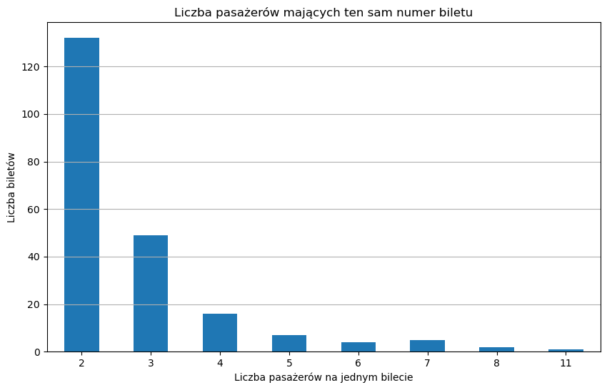

```python
# Group by ticket and count the number of people sharing the same ticket
ticket_groups = df.groupby('Numer biletu').size()

# Filter out tickets that are shared by more than one person
shared_tickets = ticket_groups[ticket_groups > 1]

# Plotting
plt.figure(figsize=(10, 6))
shared_tickets.value_counts().sort_index().plot(kind='bar')
plt.title('Liczba pasażerów mających ten sam numer biletu')
plt.xlabel('Liczba pasażerów na jednym bilecie')
plt.ylabel('Liczba biletów')
plt.xticks(rotation=0)
plt.grid(axis='y')

# Save the plot as a PNG file
plt.savefig('shared_tickets_chart.png')
```

```python
print(df.info())
```

```
<class 'pandas.core.frame.DataFrame'>
RangeIndex: 1310 entries, 0 to 1309
Data columns (total 14 columns):
 #   Column                     Non-Null Count  Dtype
---  ------                     --------------  -----
 0   Klasa biletu               1309 non-null   float64
 1   Przeżył ?                  1309 non-null   float64
 2   Imię i nazwisko            1309 non-null   object
 3   Płeć                       1309 non-null   object
 4   Wiek                       1046 non-null   float64
 5   Ilość-rodzeństwo/małżonek  1309 non-null   float64
 6   Ilość-rodziców/dzieci      1309 non-null   float64
 7   Numer biletu               1309 non-null   object
 8   Cena biletu                1308 non-null   float64
 9   Numer kabiny               295 non-null    object
 10  Port wejścia pasażera      1307 non-null   object
 11  Nr łodzi ratunkowej        486 non-null    object
 12  Numer ciała                121 non-null    float64
 13  Miejsce docelowe           745 non-null    object
dtypes: float64(7), object(7)
memory usage: 143.4+ KB
None
```

```
   Wyświetlamy informacje o kolumnach, liczbie wierszy, typach danych kolumny i ilości pamięci zajmowanych przez dane.
```

```python
typ_danych = df['Wiek'].dtype
print(f'Typ danych kolumny "wiek": {typ_danych}')
```

```
Typ danych kolumny "wiek": float64
```

```python
typ_danych = df['Imię i nazwisko'].dtype
print(f'Typ danych kolumny "Imię i nazwisko": {typ_danych}')
```

```
Typ danych kolumny "Imię i nazwisko": object
```

```python
df.head(3)
```

|  | Klasa biletu | Przeżył ? | Imię i nazwisko | Płeć | Wiek | Ilość-rodzeństwo/małżonek | Ilość-rodziców/dzieci | Numer biletu | Cena biletu | Numer kabiny | Port wejscia pasażera | Nr łodzi ratunkowej | Numer ciała | Miejsce docelowe |
| --- | --- | --- | --- | --- | --- | --- | --- | --- | --- | --- | --- | --- | --- | --- |
| 0 | 1.0 | 1.0 | Allen, Miss. Elisabeth Walton | female | 29.0000 | 0.0 | 0.0 | 24160 | 211.3375 | B5 | S | 2 | NaN | St Louis, MO |
| 1 | 1.0 | 1.0 | Allison, Master. Hudson Trevor | male | 0.9167 | 1.0 | 2.0 | 113781 | 151.5500 | C22 C26 | S | 11 | NaN | Montreal, PQ / Chesterville, ON |
| 2 | 1.0 | 0.0 | Allison, Miss. Helen Loraine | female | 2.0000 | 1.0 | 2.0 | 113781 | 151.5500 | C22 C26 | S | NaN | NaN | Montreal, PQ / Chesterville, ON |

Dostosowujemy formaty danych w kolumnach do bardziej czytelnych lub właściwszych do wyświetlenia. Np. Klasa biletu - 1,2,3 itd.

```python
print(df['Klasa biletu'])
```

```
0       1.0
1       1.0
2       1.0
3       1.0
4       1.0
       ...
1305    3.0
1306    3.0
1307    3.0
1308    3.0
1309    NaN
Name: Klasa biletu, Length: 1310, dtype: float64
```

```
 Sprawdzimy przed formatowaniem kolumny ile wartośći przyjmują dane w tej konkretnej kolumnie.
```

```python
df['Klasa biletu'].unique()
```

[output not shown]

Mamy trzy wartości wartości liczbowe i pola z brakiem danych oznaczanych - 'nan'.

```python
#df["Klasa biletu"] = df["Klasa biletu"].astype(int)
# Konwertujemy wartość w kolumnie zmiennoprzecinkowe
# (float) na wartości całkowite (int).
# Niestety mamy dwa typy danych przez co brak danych unimożliwi nam formatowanie
# kolumny w ten sposób
# Zamieńmy puste wartości nan na liczbę 0 co powinno umożliwić formatowanie tej kolumny
```

```python
df['Klasa biletu'] = df['Klasa biletu'].fillna(0)
# Tutaj zmieniamy wartości null (NaN) w kolumnie o nazwie 'Klasa biletu'
# na 0. Wykorzystujemy do tego metodę 'fillna(0)' z biblioteki pandas,
# która wypełnia każdą pustą wartość (NaN) w wybranej kolumnie zerem.
```

Decydujemy się na wypełnienie pustych miejsc w kolumnie "Klasa biletu" liczbą "0". To ujednolici nam typ danych w kolumnie.

```python
df['Klasa biletu'].unique()
```

```
array([1., 2., 3., 0.])
```

Wynik po zamianie wartości NaN na zero.

```python
print(df['Klasa biletu'])
```

```
0       1.0
1       1.0
2       1.0
3       1.0
4       1.0
       ...
1305    3.0
1306    3.0
1307    3.0
1308    3.0
1309    0.0
Name: Klasa biletu, Length: 1310, dtype: float64
```

```
 Efektem tego formatowania jest zamiania braku wartości w np. wierszu 1309 liczbą "0"
```

```python
print(df.dtypes) # Wyświetlemy typy danych w każdej kolumnie
# Mamy tutaj dwa rodzaje danych - float(liczba zmiennprzecinkowa)
# Oraz object
```

```
Klasa biletu                 float64
Przeżył ?                    float64
Imię i nazwisko               object
Płeć                          object
Wiek                         float64
Ilość-rodzeństwo/małżonek    float64
Ilość-rodziców/dzieci        float64
Numer biletu                  object
Cena biletu                  float64
Numer kabiny                  object
Port wejscia pasażera         object
Nr łodzi ratunkowej           object
Numer ciała                  float64
Miejsce docelowe              object
dtype: object
```

```python
df['Klasa biletu'] = df['Klasa biletu'].astype(int)
# Zmieniliśmy typ danych w tej kolumnie na liczby całkowite
# bo innych liczb nie mamy w tej kolumnie
```

```
Zmieniamy typ danych w kolumnie "Klasa biletu" na liczby całkowite.
```

```python
print(df['Klasa biletu'])
```

[output not shown]

Wartości kolumny po zamianie na liczby całkowite.

```python
df.head(3)
```

|  | Klasa biletu | Przeżył ? | Imię i nazwisko | Płeć | Wiek | Ilość-rodzeństwo/małżonek | Ilość-rodziców/dzieci | Numer biletu | Cena biletu | Numer kabiny | Port wejscia pasażera | Nr łodzi ratunkowej | Numer ciała | Miejsce docelowe |
| --- | --- | --- | --- | --- | --- | --- | --- | --- | --- | --- | --- | --- | --- | --- |
| 0 | 1 | 1.0 | Allen, Miss. Elisabeth Walton | female | 29.0000 | 0.0 | 0.0 | 24160 | 211.3375 | B5 | S | 2 | NaN | St Louis, MO |
| 1 | 1 | 1.0 | Allison, Master. Hudson Trevor | male | 0.9167 | 1.0 | 2.0 | 113781 | 151.5500 | C22 C26 | S | 11 | NaN | Montreal, PQ / Chesterville, ON |
| 2 | 1 | 0.0 | Allison, Miss. Helen Loraine | female | 2.0000 | 1.0 | 2.0 | 113781 | 151.5500 | C22 C26 | S | NaN | NaN | Montreal, PQ / Chesterville, ON |

```python
print(type('Przeżył ?'))
# Sprawdzamy jakiego rodzaju dane typu ogólnego'object' zawiera kolumna "Przeżył ?"
```

```
<class 'str'>
```

```python
df.sample(3)
```

|  | Klasa biletu | Przeżył ? | Imię i nazwisko | Płeć | Wiek | Ilość-rodzeństwo/małżonek | Ilość-rodziców/dzieci | Numer biletu | Cena biletu | Numer kabiny | Port wejscia pasażera | Nr łodzi ratunkowej | Numer ciała | Miejsce docelowe |
| --- | --- | --- | --- | --- | --- | --- | --- | --- | --- | --- | --- | --- | --- | --- |
| 252 | 1 | 0.0 | Ryerson, Mr. Arthur Larned | male | 61.0 | 1.0 | 3.0 | PC 17608 | 262.3750 | B57 B59 B63 B66 | C | NaN | NaN | Haverford, PA / Cooperstown, NY |
| 1129 | 3 | 0.0 | Petterson, Mr. Johan Emil | male | 25.0 | 1.0 | 0.0 | 347076 | 7.7750 | NaN | S | NaN | NaN | NaN |
| 492 | 2 | 1.0 | Mallet, Master. Andre | male | 1.0 | 0.0 | 2.0 | S.C./PARIS 2079 | 37.0042 | NaN | C | 10 | NaN | Paris / Montreal, PQ |

```python
liczba_brakujących_danych = df['Przeżył ?'].isnull().sum()
print(liczba_brakujących_danych)
# sprawdzamy ile brakuje nam danych w kolumnie "Przeżył"
```

```
1
```

Sprawdzamy ile brakuje nam danych w kolumnie "Przeżył" oraz pozostałych kolumn.

```python
liczba_brakujących_danych_wg_kolumn = df.isnull().sum()
print(liczba_brakujących_danych_wg_kolumn)
# sprawdzamy ile brakuje nam danych we wszystkich kolumnach
```

```
Klasa biletu                    0
Przeżył ?                       1
Imię i nazwisko                 1
Płeć                            1
Wiek                          264
Ilość-rodzeństwo/małżonek       1
Ilość-rodziców/dzieci           1
Numer biletu                    1
Cena biletu                     2
Numer kabiny                 1015
Port wejścia pasażera           3
Nr łodzi ratunkowej           824
Numer ciała                  1189
Miejsce docelowe              565
dtype: int64
```

Zaskakuje duży brak danych w kolumnie - wiek. Czyżby pasażerowie z wyższych sfer nie mieli w zwyczaju podawać takich danych ? Spróbujmy zaraz sprawdzić ten wątek.... Chciałbym również się dowiedzieć z czego wynika brak większości danych o numerach kabin, w których spędzali podróż pasażerowie.

Czy brak danych jest aż tak duży. Wyróbmy sobie zdanie w oparciu o wykres...

[figure not shown]

```python
# Calculate the number of missing values for each column
missing_data = df.isnull().sum()

# Create a heatmap to visualize missing data
plt.figure(figsize=(10, 8))
sns.heatmap(df.isnull(), cbar=True, cmap='Blues', yticklabels=False)

# Annotate the heatmap with the number of missing values for each column
for i, col in enumerate(df.columns):
    plt.text(i + 0.5, -0.5, f"{missing_data[col]}", ha='center', va='center', color='black')

plt.title('Heatmap of Missing Data')
plt.xlabel('Kolumny')
plt.ylabel('Wiersze')
plt.xticks(rotation=45)
plt.tight_layout()

# Save the plot as a PNG file
plt.savefig("missing_data_heatmap.png")
```

Niekompletność danych w tych czterech kolumnach pokazanych na wykresie może być wyzwaniem.

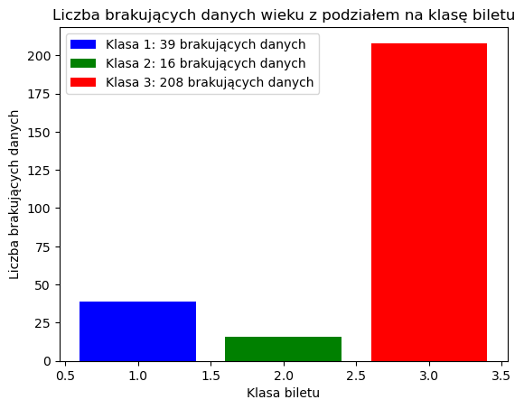

```python
# Count missing values in 'age' column grouped by 'pclass'
missing_age_by_class = df[df['Wiek'].isnull()].groupby('Klasa biletu').size()

# Plotting
colors = ['blue', 'green', 'red']  # Different colors for each class
fig, ax = plt.subplots()

# Create a bar plot
bars = ax.bar(missing_age_by_class.index, missing_age_by_class.values, color=colors)

# Add numbers to the legend
legend_labels = [f'Klasa {int(pclass)}: {count} brakujących danych' for pclass, count in zip(missing_age_by_class.index, missing_age_by_class.values)]
ax.legend(bars, legend_labels)

# Set labels and title
ax.set_xlabel('Klasa biletu')
ax.set_ylabel('Liczba brakujących danych')
ax.set_title('Liczba brakujących danych wieku z podziałem na klasę biletu')

# Save the plot as a PNG file
plt.savefig('missing_age_by_class.png')
```

Dane mówią coś zupełnie przeciwnego (niż moje przypuszczenie) - to u posiadaczy biletów trzeciej klasy brakuje najwięcej danych wieku.

```python
print(df.count()) # Wyświetlamy ile mamy wierszy z danymi żeby obliczyć procent
# brakujących danych
```

```
Klasa biletu                 1310
Przeżył ?                    1309
Imię i nazwisko              1309
Płeć                         1309
Wiek                         1046
Ilość-rodzeństwo/małżonek    1309
Ilość-rodziców/dzieci        1309
Numer biletu                 1309
Cena biletu                  1308
Numer kabiny                  295
Port wejscia pasażera        1307
Nr łodzi ratunkowej           486
Numer ciała                   121
Miejsce docelowe              745
dtype: int64
```

Sprawdzamy ile mamy wierszy z danymi i bez danych...

```python
missing_data = df.isnull().sum() / len(df) * 100
missing_data = missing_data.round(2)
# Wyświetlamy zestawienie % brakujących danych
print(missing_data)
```

```
Klasa biletu                  0.00
Przeżył ?                     0.08
Imię i nazwisko               0.08
Płeć                          0.08
Wiek                         20.15
Ilość-rodzeństwo/małżonek     0.08
Ilość-rodziców/dzieci         0.08
Numer biletu                  0.08
Cena biletu                   0.15
Numer kabiny                 77.48
Port wejscia pasażera         0.23
Nr łodzi ratunkowej          62.90
Numer ciała                  90.76
Miejsce docelowe             43.13
dtype: float64
```

```
       Mamy kilka kolumn z bardzo dużym procentem brakujących danych:
```

- Wiek - 20,15%
- Numer kabiny - 77,48%
- Nr łodzi ratunkowej - 62,90%
- Nr ciała - 90,76%
- Miejsce docelowe - 43,13 %

W dalszej analizie danych procent ten będziemy musieli starannie uwzględnić w decyzjach o pobieraniu danych z tych kolumn. W kolumnie wiek możemy uśrednić wiek, choć nie wiem czy po prostu nie opuszczać tych wierszy z brakującymi danymi do tworzenia wykresów.

```python
missing_data = df[df['Przeżył ?'].isnull()].T
print(missing_data) #Wyświetlamy wiersze z brakującymi danymmi w kolumnie
# "Przeżył?"
```

```
                          1309
Klasa biletu               NaN
Przeżył ?                  NaN
Imię i nazwisko            NaN
Płeć                       NaN
Wiek                       NaN
Ilość-rodzeństwo/małżonek  NaN
Ilość-rodziców/dzieci      NaN
Numer biletu               NaN
Cena biletu                NaN
Numer kabiny               NaN
Port wejścia pasażera      NaN
Nr łodzi ratunkowej        NaN
Numer ciała                NaN
Miejsce docelowe           NaN
```

Wracamy do kolumny "Przeżył" i sprawdzamy dokładnie w jakich wierszach brakuje nam danych.

```python
print(type('1309')) # Sprawdzamy jakiego typu dane są w tym wierszu
```

```
<class 'str'>
```

Tylko wiersz o indeksie 1309 nie zawiera danych i jak się okazuje nie tylko w kolumnie "Przeżył" ale we wszystkich pozostałych też. Jest doskonały kandydat do usunięcia z df.

```python
df=df.drop(1309) # Usuwamy wiersz o indeksie 1309 z poprawioną linijką kodu
# można by jeszcze tak...
# df=df.dropna(how='all') powinno usuną wszystkie wiersze w których wszystkie
# wartośći to NaN
```

[output not shown]

[output cut: 14 more lines]

[output not shown]

Usuwamy wiersz o indeksie 1309.

```python
index_to_check = 1309

# Sprawdzenie, czy indeks istnieje i wyświetlenie wiersza
if index_to_check in df.index:
    row = df.loc[index_to_check]
    print(row)
else:
    print(f"Indeks {index_to_check} nie istnieje w DataFrame.")
```

```
Indeks 1309 nie istnieje w DataFrame.
```

```
      Sprawdzamy czy usunęliśmy wiersz o indeksie 1309 z df
```

```python
liczba_brakujących_danych_wg_kolumn = df.isnull().sum()
print(liczba_brakujących_danych_wg_kolumn)
# sprawdzamy ile brakuje nam danych we wszystkich kolumnach
```

[output not shown]

W tych kolumnach brakuje następującej ilości danych:

Spróbujmy przyjrzeć się tym kolumnom i wierszom, i zamiast je kasować zobaczmy czy możemy te dane w jakiś sposób uzupełnić.

```python
missing_data = df[df['Imię i nazwisko'].isnull()]
print(missing_data)   #Wyświetlamy te wiersze gdzie brakują dane
```

```
Empty DataFrame
Columns: [Klasa biletu, Przeżył ?, Imię i nazwisko, Płeć, Wiek, Ilość-rodzeństwo/małżonek, Ilość-rodziców/dzieci, Numer biletu, Cena biletu, Numer kabiny, Port wejścia pasażera, Nr łodzi ratunkowej, Numer ciała, Miejsce docelowe]
Index: []
```

```python
missing_data = df[df['Płeć'].isnull()]
print(missing_data)   #Wyświetlamy te wiersze gdzie brakują dane
```

[output not shown]

```python
missing_data = df[df['Ilość-rodzeństwo/małżonek'].isnull()]
print(missing_data)   #Wyświetlamy te wiersze gdzie brakują dane
```

[output not shown]

```python
missing_data = df[df['Ilość-rodziców/dzieci'].isnull()]
print(missing_data)   #Wyświetlamy te wiersze gdzie brakują dane
```

```
Empty DataFrame
Columns: [Klasa biletu, Przeżył ?, Imię i nazwisko, Płeć, Wiek, Ilość-rodzeństwo/małżonek, Ilość-rodziców/dzieci, Numer biletu, Cena biletu, Numer kabiny, Port wejścia pasażera, Nr łodzi ratunkowej, Numer ciała, Miejsce docelowe]
Index: []
```

```python
missing_data = df[df['Numer biletu'].isnull()]
print(missing_data)   #Wyświetlamy te wiersze gdzie brakują dane
```

```
Empty DataFrame
Columns: [Klasa biletu, Przeżył ?, Imię i nazwisko, Płeć, Wiek, Ilość-rodzeństwo/małżonek, Ilość-rodziców/dzieci, Numer biletu, Cena biletu, Numer kabiny, Port wejścia pasażera, Nr łodzi ratunkowej, Numer ciała, Miejsce docelowe]
Index: []
```

```python
missing_data = df[df['Cena biletu'].isnull()]
print(missing_data)   #Wyświetlamy te wiersze gdzie brakują dane
```

```
      Klasa biletu  Przeżył ?     Imię i nazwisko  Płeć  Wiek  \
1225             3        0.0  Storey, Mr. Thomas  male  60.5

      Ilość-rodzeństwo/małżonek  Ilość-rodziców/dzieci Numer biletu  \
1225                        0.0                    0.0         3701

      Cena biletu Numer kabiny Port wejścia pasażera Nr łodzi ratunkowej  \
1225          NaN          NaN                     S                 NaN

      Numer ciała Miejsce docelowe
1225        261.0              NaN
```

W kolumnie "Cena biletu" znaleźliśmy wiersz o indeksie 1225 z brakującymi danymi, które należy rozpatrzyć. Sprawdźmy jaka jest średnia cena biletu i rozpiętość cenowa i czy możemy zastąpić brak danych jakąś wartością uśrednioną.

```python
print(df['Cena biletu'].describe().round(2)) #wyświetla statystyki dla kolumny Cena biletu
```

```
count    1308.00
mean       33.30
std        51.76
min         0.00
25%         7.90
50%        14.45
75%        31.28
max       512.33
Name: Cena biletu, dtype: float64
```

Widzimy jakąś błędną daną w wartości min. Zrobimy poprawione statystyki tej kolumny ale bez tej błędnej wartości.

```python
filtered_df = df[df['Cena biletu'] != 0]

# Now, display the summary statistics for the 'Cena' column.
summary = filtered_df['Cena biletu'].describe().round(2)
print(summary)
```

```
count    1291.00
mean       33.73
std        51.96
min         3.17
25%         7.92
50%        14.50
75%        31.33
max       512.33
Name: Cena biletu, dtype: float64
```

Rozpiętość ceny biletu jest bardzo duża. Możemy sprecyzować cenę znając klasę biletu i wykonać uśrednienie tylko dla biletów z klasy trzeciej.

```python
class_3_fares = df[(df['Klasa biletu'] == 3) & (df['Cena biletu'] > 0)]['Cena biletu']

# Calculate the mean fare, rounded to two decimal places
Średnia_cena_biletów_3_klasy = round(class_3_fares.mean(), 2)
print(Średnia_cena_biletów_3_klasy)
```

```
13.38
```

```
               13.38 to średnia cena biletu dla klasy 3.
  Sprawdzimy jeszcze rozpiętość ceny biletu dla lepszej orientacji.
```

```python
third_class_fares = df[(df['Klasa biletu'] == 3) & (df['Cena biletu'] > 0) & (df['Cena biletu'].notnull())]

# Calculate the minimum and maximum fare
min_fare = third_class_fares['Cena biletu'].min()
max_fare = third_class_fares['Cena biletu'].max()

# Declare result var
result = f"Min to {min_fare}, Max to {max_fare}."

print(result)
```

```
Min to 3.1708, Max to 69.55.
```

Jak widzimy średnia jest dużo bliżej ceny minimalnej. Właściwsze byłoby tu zastosowanie wyniku mediany do uzupełnienia brakującej ceny biletu.

```python
mediana_ceny_biletu_w_klasie_3 = df[df['Klasa biletu'] == 3]['Cena biletu'].median()
# obliczamy średnią cenę biletu w klasie trzeciej, pomijając zero i brak danych
print(mediana_ceny_biletu_w_klasie_3)
```

```
8.05
```

Spodziewałem się innego wyniku ale uzupełnię brakujący wiersz o indeksie 1225 obiczoną medianą ceny biletów klasy 3 - 8.05

```python
df.at[1225, 'Cena biletu'] = 8.05
```

```python
wiersz = df.loc[1225] #wyświetlamy wiersz 1225 żeby sprawdzić czy
# zaktualizowała się brakująca cena biletu
print(wiersz)
```

[output not shown]

```
         Cena biletu dla wiersza o indeksie 1225 jest uzupełniona.
```

```python
print(type('Cena biletu'))
```

```
<class 'str'>
```

Typ danych w kolumnie "Cena biletu" to str (string). Jeżeli w kolumnie są same wartości liczbowe to warto zmienić typ danch na liczbowy.

```python
df['Cena biletu'] = pd.to_numeric(df['Cena biletu'], errors='coerce')
# Zamieniamy dane z kolumny Cena biletu na typ liczbowy
# Round the 'Cena' column to 2 decimal places
df['Cena biletu'] = df['Cena biletu'].round(2)
```

```python
print(type('Cena biletu'))
```

```
<class 'str'>
```

```python
print(df.dtypes)
```

```
Klasa biletu                   int32
Przeżył ?                    float64
Imię i nazwisko               object
Płeć                          object
Wiek                         float64
Ilość-rodzeństwo/małżonek    float64
Ilość-rodziców/dzieci        float64
Numer biletu                  object
Cena biletu                  float64
Numer kabiny                  object
Port wejścia pasażera         object
Nr łodzi ratunkowej           object
Numer ciała                  float64
Miejsce docelowe              object
dtype: object
```

Cena biletu jest typu float64, a w poprzedniej linijce str (?) Skąd to wynika ?

```python
# df = np.floor(pd.to_numeric(df['Cena biletu'], errors='coerce')).astype('Int64')
# Jeszcze jedna próba zmiany danych na typ liczbowy
```

```python
missing_data = df[df['Port wejścia pasażera'].isnull()]
print(missing_data)   #Wyświetlamy te wiersze gdzie brakują dane
```

```
     Klasa biletu  Przeżył ?                            Imię i nazwisko  \
168             1        1.0                        Icard, Miss. Amelie
284             1        1.0  Stone, Mrs. George Nelson (Martha Evelyn)

       Płeć  Wiek  Ilość-rodzeństwo/małżonek  Ilość-rodziców/dzieci  \
168  female  38.0                        0.0                    0.0
284  female  62.0                        0.0                    0.0

    Numer biletu  Cena biletu Numer kabiny Port wejścia pasażera  \
168       113572         80.0          B28                   NaN
284       113572         80.0          B28                   NaN

    Nr łodzi ratunkowej  Numer ciała Miejsce docelowe
168                   6          NaN              NaN
284                   6          NaN   Cincinatti, OH
```

W kolumnie 'Port wejścia pasażera mamy dwa wiersze z brakującymi danymi. Przyjrzyjmy się im.

```python
wiersz = df.loc[168] #wyświetlamy wiersz 168
print(wiersz)
```

```
Klasa biletu                                   1
Przeżył ?                                    1.0
Imię i nazwisko              Icard, Miss. Amelie
Płeć                                      female
Wiek                                        38.0
Ilość-rodzeństwo/małżonek                    0.0
Ilość-rodziców/dzieci                        0.0
Numer biletu                              113572
Cena biletu                                 80.0
Numer kabiny                                 B28
Port wejscia pasażera                        NaN
Nr łodzi ratunkowej                            6
Numer ciała                                  NaN
Miejsce docelowe                             NaN
Name: 168, dtype: object
```

Uzupełnimy brakującą dane w wierszu 168. Sprawdziłem, że ta pasażerka weszła na pokład Tytanica w Southampton. (S)

```python
df.loc[168, 'Port wejścia pasażera'] = 'S'
# Wpisujemy w wiersz 168 i kolumnę Port wejscia pasażera brakujące dane
```

```python
wiersz = df.loc[168]
print(wiersz)
```

[output not shown]

Sprawdzamy czy dane są wpisane.

```python
wiersz = df.loc[284]
print(wiersz)
```

[output not shown]

```python
df.loc[284, 'Port wejścia pasażera'] = 'S'
# Wpisujemy w wiersz 168 i kolumnę Port wejscia pasażera brakujące dane
```

Uzupełnimy brakującą dane w wierszu 284. Sprawdziłem, że ta pasażerka weszła na pokład Tytanica w Southampton. (S)

```python
wiersz = df.loc[284]
print(wiersz)
```

[output not shown]

Dane wiersza o indeksie 284 są uzupełnione. Co ciekawe wiersze 284 i 168 łączyło coś więcej niż wspólny brak danych portu wejścia na pokład. Obie panie mieszkały w tej samej kabinie nr. B28 i podróżowały na wspólnym bilecie. Obu paniom udało się przeżyć katastrofę będąc w tej samej łodzi ratunkowej. Patrząc na wiek obu pań oraz dane w kolumnach(Ilość-rodzeństwo/małżonekIlość-rodziców/dzieci) można podejrzewać, że młodsza z pań skoro nie była spokrewniona ze starszą to mogła być jej np. służącą.

```python
df['Przeżył ?'] = df['Przeżył ?'].replace({1.0: 'Tak', 0.0: 'Nie'})
# Zmieniamy wartośći 1 i 0 w kolumnie na bardziej odpowiednie do kolumny Przeżył.
```

```
     Zmieniamy wartość w kolumnie przeżył "1" i "0' na bardziej dla nas czytelne - "Tak" i "Nie"
```

```python
df.sample(3)
```

|  | Klasa biletu | Przeżył ? | Imię i nazwisko | Płeć | Wiek | Ilość-rodzeństwo/małżonek | Ilość-rodziców/dzieci | Numer biletu | Cena biletu | Numer kabiny | Port wejscia pasażera | Nr łodzi ratunkowej | Numer ciała | Miejsce docelowe | Port wejścia pasażera |
| --- | --- | --- | --- | --- | --- | --- | --- | --- | --- | --- | --- | --- | --- | --- | --- |
| 179 | 1 | Nie | Klaber, Mr. Herman | male | NaN | 0.0 | 0.0 | 113028 | 26.55 | C124 | S | NaN | NaN | Portland, OR | NaN |
| 591 | 2 | Tak | West, Miss. Constance Mirium | female | 5.0 | 1.0 | 2.0 | C.A. 34651 | 27.75 | NaN | S | 10 | NaN | Bournmouth, England | NaN |
| 901 | 3 | Nie | Johnston, Miss. Catherine Helen "Carrie" | female | NaN | 1.0 | 2.0 | W./C. 6607 | 23.45 | NaN | S | NaN | NaN | NaN | NaN |

```
             Sprawdzamy efekty zmian w kolumnie "Przeżył".
```

```python
print(df.index) #Sprawdzamy listę wierszy po indeksie
```

```
RangeIndex(start=0, stop=1309, step=1)
```

```python
df.tail(3)
```

|  | Klasa biletu | Przeżył ? | Imię i nazwisko | Płeć | Wiek | Ilość-rodzeństwo/małżonek | Ilość-rodziców/dzieci | Numer biletu | Cena biletu | Numer kabiny | Port wejscia pasażera | Nr łodzi ratunkowej | Numer ciała | Miejsce docelowe | Port wejścia pasażera |
| --- | --- | --- | --- | --- | --- | --- | --- | --- | --- | --- | --- | --- | --- | --- | --- |
| 1306 | 3 | Nie | Zakarian, Mr. Mapriededer | male | 26.5 | 0.0 | 0.0 | 2656 | 7.22 | NaN | C | NaN | 304.0 | NaN | NaN |
| 1307 | 3 | Nie | Zakarian, Mr. Ortin | male | 27.0 | 0.0 | 0.0 | 2670 | 7.22 | NaN | C | NaN | NaN | NaN | NaN |
| 1308 | 3 | Nie | Zimmerman, Mr. Leo | male | 29.0 | 0.0 | 0.0 | 315082 | 7.88 | NaN | S | NaN | NaN | NaN | NaN |

```python
print(type('Płeć'))
```

```
<class 'str'>
```

```
  Kolejna nazwa kolumny do zmiany z języka angielskiego na polski.
```

```python
df['Płeć'] = df['Płeć'].replace({'male': 'Mężczyzna', 'female': 'Kobieta'})
```

```python
df.head(3) #Sprawdzamy czy jest ok.
```

|  | Klasa biletu | Przeżył ? | Imię i nazwisko | Płeć | Wiek | Ilość-rodzeństwo/małżonek | Ilość-rodziców/dzieci | Numer biletu | Cena biletu | Numer kabiny | Port wejscia pasażera | Nr łodzi ratunkowej | Numer ciała | Miejsce docelowe | Port wejścia pasażera |
| --- | --- | --- | --- | --- | --- | --- | --- | --- | --- | --- | --- | --- | --- | --- | --- |
| 0 | 1 | Tak | Allen, Miss. Elisabeth Walton | Kobieta | 29.0000 | 0.0 | 0.0 | 24160 | 211.34 | B5 | S | 2 | NaN | St Louis, MO | NaN |
| 1 | 1 | Tak | Allison, Master. Hudson Trevor | Mężczyzna | 0.9167 | 1.0 | 2.0 | 113781 | 151.55 | C22 C26 | S | 11 | NaN | Montreal, PQ / Chesterville, ON | NaN |
| 2 | 1 | Nie | Allison, Miss. Helen Loraine | Kobieta | 2.0000 | 1.0 | 2.0 | 113781 | 151.55 | C22 C26 | S | NaN | NaN | Montreal, PQ / Chesterville, ON | NaN |

Sprawdzamy czy po zmianie nazw jest ok.

```python
df['Wiek'] = df['Wiek'].round(1) #zmieniamy wyświetlanie danych z
# kolumny wiek do jednego miejsca po przecinku. To pozwoli nam wyświetlać również
# dzieci poniżej 1 roku życia
```

Zmieniamy wyświetlanie danych z kolumny "Wiek" do jednego miejsca po przecinku. To pozwoli nam wyświetlać również dzieci poniżej 1 roku życia

```python
df.head(2)
```

|  | Klasa biletu | Przeżył ? | Imię i nazwisko | Płeć | Wiek | Ilość-rodzeństwo/małżonek | Ilość-rodziców/dzieci | Numer biletu | Cena biletu | Numer kabiny | Port wejscia pasażera | Nr łodzi ratunkowej | Numer ciała | Miejsce docelowe | Port wejścia pasażera |
| --- | --- | --- | --- | --- | --- | --- | --- | --- | --- | --- | --- | --- | --- | --- | --- |
| 0 | 1 | Tak | Allen, Miss. Elisabeth Walton | Kobieta | 29.0 | 0.0 | 0.0 | 24160 | 211.34 | B5 | S | 2 | NaN | St Louis, MO | NaN |
| 1 | 1 | Tak | Allison, Master. Hudson Trevor | Mężczyzna | 0.9 | 1.0 | 2.0 | 113781 | 151.55 | C22 C26 | S | 11 | NaN | Montreal, PQ / Chesterville, ON | NaN |

```python
print(type('Ilość-rodzeństwo/małżonek'))
```

```
<class 'str'>
```

Zmieniamy dane w kolumnie "Ilość-rodzeństwo/małżonek" na typ liczbowy.

```python
# df['Ilość-rodzeństwo/małżonek'] = df['Ilość-rodzeństwo/małżonek'].apply(lambda x: int(float(x)) if pd.notna(x) else np.nan)
df['Ilość-rodzeństwo/małżonek'] = pd.to_numeric(df['Ilość-rodzeństwo/małżonek'], errors='coerce')
```

```python
df.head(1)
```

|  | Klasa biletu | Przeżył ? | Imię i nazwisko | Płeć | Wiek | Ilość-rodzeństwo/małżonek | Ilość-rodziców/dzieci | Numer biletu | Cena biletu | Numer kabiny | Port wejscia pasażera | Nr łodzi ratunkowej | Numer ciała | Miejsce docelowe | Port wejścia pasażera |
| --- | --- | --- | --- | --- | --- | --- | --- | --- | --- | --- | --- | --- | --- | --- | --- |
| 0 | 1 | Tak | Allen, Miss. Elisabeth Walton | Kobieta | 29.0 | 0.0 | 0.0 | 24160 | 211.34 | B5 | S | 2 | NaN | St Louis, MO | NaN |

```python
missing_data = df[df['Ilość-rodzeństwo/małżonek'].isnull()]
print(missing_data)   #Wyświetlamy te wiersze gdzie brakują dane
```

```
Empty DataFrame
Columns: [Klasa biletu, Przeżył ?, Imię i nazwisko, Płeć, Wiek, Ilość-rodzeństwo/małżonek, Ilość-rodziców/dzieci, Numer biletu, Cena biletu, Numer kabiny, Port wejścia pasażera, Nr łodzi ratunkowej, Numer ciała, Miejsce docelowe]
Index: []
```

Sprawdzamy czy w kolmnie Ilość-rodzeństwo/małżonek brakują dane. Odpowiedź - Nie brakują.

```python
df['Ilość-rodzeństwo/małżonek'] = pd.to_numeric(df['Ilość-rodzeństwo/małżonek']
                                                , errors='coerce').astype('Int64')
# Zamienia wartośći w kolumnie na liczby, jeśli napotka na wartości, które
# nie mogą być zmienione to zastępuje je wartością NaN i konwertuje te
# Liczby na typ Int64
```

```python
missing_data = df[df['Ilość-rodziców/dzieci'].isnull()]
print(missing_data)  #Wyświetlamy te wiersze gdzie brakują dane
```

```
Empty DataFrame
Columns: [Klasa biletu, Przeżył ?, Imię i nazwisko, Płeć, Wiek, Ilość-rodzeństwo/małżonek, Ilość-rodziców/dzieci, Numer biletu, Cena biletu, Numer kabiny, Port wejścia pasażera, Nr łodzi ratunkowej, Numer ciała, Miejsce docelowe]
Index: []
```

Sprawdzamy czy mamy jakiś brak danych w kolumnie - "Ilosć-rodzicó/dzieci". Odp. Nie mamy.

```python
df['Ilość-rodziców/dzieci'] = pd.to_numeric(df['Ilość-rodziców/dzieci']
                                                , errors='coerce').astype('Int64')
```

Tak samo formatujemy dane w kolumnie Ilość-rodziców/dzieci

```python
df['Ilość-rodziców/dzieci'] = df['Ilość-rodziców/dzieci'].astype(int)
```

Zmieniamy dane w kolejnej kolumnie, tym razem w - Ilość-rodziców/dzieci na liczby całkowite.

```python
pd.set_option('display.max_rows', 100) # Chciałem zobaczyć 100 wierszy :-)
df.sample(5) # Wyświetlamy losowych 10 wierszy by srpawdzić czy formatowanie
# się udało
```

|  | Klasa biletu | Przeżył ? | Imię i nazwisko | Płeć | Wiek | Ilość-rodzeństwo/małżonek | Ilość-rodziców/dzieci | Numer biletu | Cena biletu | Numer kabiny | Port wejścia pasażera | Nr łodzi ratunkowej | Numer ciała | Miejsce docelowe |
| --- | --- | --- | --- | --- | --- | --- | --- | --- | --- | --- | --- | --- | --- | --- |
| 940 | 3 | Nie | Kraeff, Mr. Theodor | Mężczyzna | NaN | 0 | 0 | 349253 | 7.90 | NaN | C | NaN | NaN | NaN |
| 323 | 2 | Nie | Abelson, Mr. Samuel | Mężczyzna | 30.0 | 1 | 0 | P/PP 3381 | 24.00 | NaN | C | NaN | NaN | Russia New York, NY |
| 835 | 3 | Nie | Guest, Mr. Robert | Mężczyzna | NaN | 0 | 0 | 376563 | 8.05 | NaN | S | NaN | NaN | NaN |
| 852 | 3 | Nie | Harknett, Miss. Alice Phoebe | Kobieta | NaN | 0 | 0 | W./C. 6609 | 7.55 | NaN | S | NaN | NaN | NaN |
| 301 | 1 | Nie | Walker, Mr. William Anderson | Mężczyzna | 47.0 | 0 | 0 | 36967 | 34.02 | D46 | S | NaN | NaN | East Orange, NJ |

```python
missing_data = df[df['Numer biletu'].isnull()]
print(missing_data)
```

```
Empty DataFrame
Columns: [Klasa biletu, Przeżył ?, Imię i nazwisko, Płeć, Wiek, Ilość-rodzeństwo/małżonek, Ilość-rodziców/dzieci, Numer biletu, Cena biletu, Numer kabiny, Port wejścia pasażera, Nr łodzi ratunkowej, Numer ciała, Miejsce docelowe]
Index: []
```

```
           Nie ma brakujących danych w kolumnie "Numer biletu"
```

```python
missing_data = df[df['Cena biletu'].isnull()]
print(missing_data) # Sprawdzamy w kolumnie jakie wiersze mamy bez danych
```

```
Empty DataFrame
Columns: [Klasa biletu, Przeżył ?, Imię i nazwisko, Płeć, Wiek, Ilość-rodzeństwo/małżonek, Ilość-rodziców/dzieci, Numer biletu, Cena biletu, Numer kabiny, Port wejścia pasażera, Nr łodzi ratunkowej, Numer ciała, Miejsce docelowe]
Index: []
```

```python
df = df.drop(1225)
```

```python
index_to_check = 1225

# Sprawdzenie, czy indeks istnieje i wyświetlenie wiersza
if index_to_check in df.index:
    row = df.loc[index_to_check]
    print(row)
else:
    print(f"Indeks {index_to_check} nie istnieje w DataFrame.")
```

```
Indeks 1225 nie istnieje w DataFrame.
```

```python
index = df.loc[1226] # Wyświetlamy wiersz numer 1226
print(index)
```

```
Klasa biletu                                    3
Przeżył ?                                     Nie
Imię i nazwisko              Stoytcheff, Mr. Ilia
Płeć                                    Mężczyzna
Wiek                                         19.0
Ilość-rodzeństwo/małżonek                       0
Ilość-rodziców/dzieci                         0.0
Numer biletu                               349205
Cena biletu                                   7.9
Numer kabiny                                  NaN
Port wejścia pasażera                           S
Nr łodzi ratunkowej                           NaN
Numer ciała                                   NaN
Miejsce docelowe                              NaN
Name: 1226, dtype: object
```

Wyświetlamy przykładowy wiersz o indeksie 1226 by przyjrzeć się jak wyglądają Nazwy kolumni i dane w kolumnach po powyższych formatowaniach.

```python
df.sample(3)
```

|  | Klasa biletu | Przeżył ? | Imię i nazwisko | Płeć | Wiek | Ilość-rodzeństwo/małżonek | Ilość-rodziców/dzieci | Numer biletu | Cena biletu | Numer kabiny | Port wejscia pasażera | Nr łodzi ratunkowej | Numer ciała | Miejsce docelowe | Port wejścia pasażera |
| --- | --- | --- | --- | --- | --- | --- | --- | --- | --- | --- | --- | --- | --- | --- | --- |
| 973 | 3 | Nie | Lithman, Mr. Simon | Mężczyzna | NaN | 0 | 0 | S.O./P.P. 251 | 7.55 | NaN | S | NaN | NaN | NaN | NaN |
| 172 | 1 | Nie | Julian, Mr. Henry Forbes | Mężczyzna | 50.0 | 0 | 0 | 113044 | 26.00 | E60 | S | NaN | NaN | London | NaN |
| 783 | 3 | Tak | Duquemin, Mr. Joseph | Mężczyzna | 24.0 | 0 | 0 | S.O./P.P. 752 | 7.55 | NaN | S | D | NaN | England Albion, NY | NaN |

```python
liczba_brakujących_danych_wg_kolumn = df.isnull().sum()
print(liczba_brakujących_danych_wg_kolumn)
# sprawdzamy ile brakuje nam danych we wszystkich kolumnach
```

```
Klasa biletu                    0
Przeżył ?                       0
Imię i nazwisko                 0
Płeć                            0
Wiek                          263
Ilość-rodzeństwo/małżonek       0
Ilość-rodziców/dzieci           0
Numer biletu                    0
Cena biletu                     0
Numer kabiny                 1013
Port wejścia pasażera           0
Nr łodzi ratunkowej           822
Numer ciała                  1188
Miejsce docelowe              563
dtype: int64
```

Sprawdzamy czy coś jeszcze możemy zrobić z brakującymi danymi. W kolumnie wiek brakuje 263 wiersze. Nie wiem czy jest wypełniać te dane np. wartością uśrednioną. Zdecydowałem, że będę pomijał te wiersze w zestawieniach, które będą miały pobierać dane z kolumny wiek. W numerze kabiny to większości wierszy brakuje danych. Nie wiem czy będę potrzebował w ogóle dancy z tej kolumny. Jeśl tak, to tylko w takim zakresie, gdzie brakujące dane nie będą problemem. Podobnie ma się z pozostałymi kolumnami. Jeżeli brakujące dane będą wpływały negatynie na zestawienia, to wprowadzę formatowanie w tych kolumnach.

```python
df.sample(50)
```

[output not shown]

Przyglądając się jeszcze pojedyńczym zmiennym, to kolumna "Nr biletu" wydaje się najbardziej trudna do formatowania i najbardziej nieuporządkowana. Mamy tu wartości liczbowe i literowe w różnym szyku. Liczb mam od 4cyfrowych do 7cyfrowych. Porównując tę kolumnę z Portem wejścia pasażera nie widzę zależności od nr biletu i miejsca jego wystawienia. Przydałoby się poznać formaty zapisu nr biletu i powiązać to z miejscem wystawienia, lub klasą biletu lub czymkolwiek.

```python
# max_value = df['Nr łodzi ratunkowej'].max()
# print("Maximum Value: ", max_value)

# To display the min value of the column
# min_value = df['Nr łodzi ratunkowej'].min()
# print("Minimal Value: ", min_value)
```

[output not shown]

[output cut: 25 more lines]

[output not shown]

Chciałem wyświetlić najmniejszy i największy nr łodzi ratunkowej. Żeby przekonać się ile ich było ale okazało się (po błędzie interpretera) , że mamy w tej kolumnie różne rodzaje danych.

```python
print(df['Nr łodzi ratunkowej'].apply(type).nunique())
# Sprawdzamy ile rodzajów typów danych mamy w tej kolumnie.
```

```
2
```

Sprawdzamy ile typów danych mamy w kolumnie oraz jakiego dokładnie typu są to dane.

```python
unique_data_types = df['Nr łodzi ratunkowej'].apply(type).unique()
# Chcę wiedzieć dokładnie jakiego różnego typu dane są w tej kolumnie
# Print the unique data types
for dtype in unique_data_types:
    print(dtype.__name__)
```

```
str
float
```

Wiemy już że mamy dwa rodzaje danych w tej kolumnie. Jeden tym to float - liczby zmiennoprzecinkowe oraz str - czyli łańcuch znaków - ciąg znaków tekstowych.

```python
# Utwórz maski dla typów danych
mask_str = df['Nr łodzi ratunkowej'].apply(lambda x: isinstance(x, str))
mask_float = df['Nr łodzi ratunkowej'].apply(lambda x: isinstance(x, float))

# Przy użyciu mask wyświetl dane
print("Dane typu str:")
print(df.loc[mask_str, 'Nr łodzi ratunkowej'])

print("\nDane typu float:")
print(df.loc[mask_float, 'Nr łodzi ratunkowej'])
```

[output not shown]

Wyświetliliśmy osobno dane typu str oraz float. Stało się jasne, że dane typu float to po prostu brak danch, który nie wziąłem pod uwagę robiąc obliczenia na danych z tej kolumny. Brak danch, z którym w tej kolumnie nic nie robiłem wpłynął na błąd w obliczaniu ilości łodzi ratunkowych. Spróbujmy brak danych zamienić na "0" by umożliwiało nam to obliczenia w tej kolumnie.

```python
df["Nr łodzi ratunkowej"] = df["Nr łodzi ratunkowej"].fillna(0)
```

```python
unique_data_types = df['Nr łodzi ratunkowej'].apply(type).unique()
# Chcę wiedzieć dokładnie jakiego różnego typu dane są w tej kolumnie
# Print the unique data types
for dtype in unique_data_types:
    print(dtype.__name__)
```

```
str
int
```

Zmienił się jeden typ danych w tej kolumnie z float na int.

```python
str_data = df.loc[df['Nr łodzi ratunkowej'].apply(lambda x: isinstance(x, str)), 'Nr łodzi ratunkowej']

# Filter the string data to retain only those that contain letters only
str_data = str_data.loc[str_data.str.isalpha()]

# Display the filtered data
print(str_data)
```

```
8       D
14      B
19      A
29      D
42      D
       ..
1256    C
1257    C
1258    C
1286    C
1299    C
Name: Nr łodzi ratunkowej, Length: 78, dtype: object
```

Wyświetlmy jakie oznaczenia literowe łodzi ratunkowych mamy w tej kolumnie.

```python
string_data = df[df['Nr łodzi ratunkowej'].apply(lambda x: isinstance(x, str))]

# Filter out data that contains only letters
only_letters = string_data[string_data['Nr łodzi ratunkowej'].apply(lambda x: x.isalpha())]

# Count and print the number of unique strings
unique_strings_count = only_letters['Nr łodzi ratunkowej'].nunique()
print(unique_strings_count)
```

```
4
```

Mamy cztery oznaczenia literowe. W kolumnie "Nr łodzi ratunkowej". Chociaż domyślam się jakie one są po wycinku z df, to jednak chciałbym mieć pewność i wyświetlimy wszystkie ich rodzaje.

```python
df_lodz = df['Nr łodzi ratunkowej'].astype(str)
df_lodz_only_letters = df_lodz[df_lodz.str.isalpha()]

# podsumuj ile rodzajów jest
types_count = df_lodz_only_letters.nunique()

# wyświetl ilość rodzajów
print(f"Ilość różnych rodzajów: {types_count}")

# wyświetl wszystkie unikalne rodzaje
print("Wszystkie rodzaje:")
print(df_lodz_only_letters.unique())
```

```
Ilość różnych rodzajów: 4
Wszystkie rodzaje:
['D' 'B' 'A' 'C']
```

Teraz wiemy że mamy 4 łodzie ratunkowe oznaczone literami zamiast cyframi. Czy może być to błędem df lub błędem spisu danych ? Sprawdźmy ile razy występują te literowe oznaczenia łodzi zamiast liczbowych, żeby wykluczyć błąd spisu.

```python
'''# Filter out
only strings
string_data = df['Nr łodzi ratunkowej'].astype(str)

# Keep only strings that contain only letters
only_letters = string_data[string_data.str.isalpha()]

# Count the unique occurrences
unique_occurrences = only_letters.nunique()

# Print the count of unique strings
print(f'Number of unique strings: {unique_occurrences}')

# Print all unique strings
print('Wszystkie rodzaje występujących liter:')
print(only_letters.unique())

# Count the occurrence of each letter in the column
letter_count = df['Nr łodzi ratunkowej'].str.upper().str.split('', expand=True).stack().value_counts()
print('Liczba występowania każdej litery:')
print(letter_count)
'''
```

[output not shown]

```python
count_A = df['Nr łodzi ratunkowej'].str.count('A').sum()

# Liczba wystąpień litery B
count_B = df['Nr łodzi ratunkowej'].str.count('B').sum()

# Liczba wystąpień litery C
count_C = df['Nr łodzi ratunkowej'].str.count('C').sum()

# Liczba wystąpień litery D
count_D = df['Nr łodzi ratunkowej'].str.count('D').sum()

print('Liczba wystąpień litery A:', count_A)
print('Liczba wystąpień litery B:', count_B)
print('Liczba wystąpień litery C:', count_C)
print('Liczba wystąpień litery D:', count_D)
```

```
Liczba wystąpień litery A: 11.0
Liczba wystąpień litery B: 10.0
Liczba wystąpień litery C: 40.0
Liczba wystąpień litery D: 22.0
```

Liczba oznaczeń literowych łodzi ratunkowych jest spora, co wyklucza pojedyncze błędy spisu, które mogły się zdarzyć przy zbieraniu danych. To jeszcze zliczmy pozostałe łodzie ratunkowe o oznaczeniu liczbowym.

```python
unique_boats = df['Nr łodzi ratunkowej'].dropna().unique()

# Calculate the number of unique lifeboats
num_unique_boats = len(unique_boats)
print(num_unique_boats)
```

```
28
```

```python
boat_numbers = df['Nr łodzi ratunkowej'].dropna()
all_boat_numbers = []
for entry in boat_numbers:
    if isinstance(entry, str):
        all_boat_numbers.extend(entry.split())
# Filter out non-numeric entries before converting to integers
numeric_boat_numbers = [num for num in all_boat_numbers if num.isdigit()]
numeric_boat_numbers = [int(num) for num in numeric_boat_numbers]
min_boat_number = min(numeric_boat_numbers)
max_boat_number = max(numeric_boat_numbers)
result = f"Najmniejszy numer łodzi ratunkowej to: {min_boat_number}  Największy numer łodzi ratunkowej to: {max_boat_number}."
print(result)
```

```
Najmniejszy numer łodzi ratunkowej to: 1  Największy numer łodzi ratunkowej to: 16.
```

Teraz wiemy (z trudnej do pozyskania danych) kolumny "Nr łodzi ratunkowej", że liczba wszystkich łodzi ratunkowych to 20. 16szt o numerach od 1 do 16 i 4szt. łodzi o oznaczeniu literowym - A, B, C, D. Ale liczba wartości unikalnych to 27. Skąd te dodatkowe 7 wartości ? Czy błąd polega na błędnych danych ? Jak to sprawdzić ?

```python
# Filter rows where the 'boat' column has more than 2 characters
filtered_df = df[df['Nr łodzi ratunkowej'].apply(lambda x: isinstance(x, str) and len(x) > 2)]
print(filtered_df['Nr łodzi ratunkowej'])
# Sposób na pokazanie błędnych wierszy jest taki że pokazuje wiersze oprócz tych co
# mają dobre dane czyli znaki od 1 do 2 w kolumnie. Np A - to jeden znak
# 16 - to dwa znaki. W ten sposób pokazuje te ciągi znaków które sa ponad
# prawidłowy zakres. :-)
```

```
86          5 9
292         5 7
293         5 7
315        8 10
746     13 15 B
820         C D
823         C D
999       15 16
1238      13 15
1277      13 15
Name: Nr łodzi ratunkowej, dtype: object
```

Wyfiltrowaliśmy nasz df aby pokazał nam tylko błędne wiersze. Jak widzimy błedne wpisy polegają na wpisaniu dwóch lub nawet trzech numerów łodzi, tak jakby wpisujący nie wiedział w jakiej dokładnie łodzi był pasażer. Mamy 10 wierszy do poprawienia. Jeżeli nie wiemy jaki numer łodzi powinien być wpisany a nie jest to jakaś wartość, którą można uśredniać, to zdecydowałem że zamiast błędnych danych lepsze będą wartości NaN.

```python
rows_to_delete = [86, 292, 293, 315, 746, 820, 823, 999, 1238, 1277]
for row in rows_to_delete:
    df.at[row, "Nr łodzi ratunkowej"] = None
```

Sprawdzamy czy kasowanie błędnych danych przebiegło prawidłowo.

```python
filtered_df = df[df['Nr łodzi ratunkowej'].apply(lambda x: isinstance(x, str) and len(x) > 2)]
print(filtered_df['Nr łodzi ratunkowej'])
```

```
Series([], Name: Nr łodzi ratunkowej, dtype: object)
```

Ok. W kolumnie - "Nr łodzi ratunkowej" nie ma już błędnych danych.

Czy same kolumny możemy do czegoś wykorzystać w zestawieniach ? Jeśli tak, to jak sformatować dane w nich zawarte ? Zobaczmy czy wszyscy co weszli na łódź ratunkową przeżyli...

[figure not shown]

```python
# Filter the DataFrame to include only passengers who entered a lifeboat
lifeboat_passengers = df[df['Nr łodzi ratunkowej'].notna()]

# Calculate the number of passengers who died after entering a lifeboat
deceased_in_lifeboat = lifeboat_passengers[lifeboat_passengers['Przeżył ?'] == 0].shape[0]

# Calculate the total number of passengers who entered a lifeboat
total_in_lifeboat = lifeboat_passengers.shape[0]

# Calculate percentages
deceased_percentage = (deceased_in_lifeboat / total_in_lifeboat) * 100
survived_percentage = 100 - deceased_percentage

# Plotting
labels = ['Przeżyli', 'Nie przeżyli']
sizes = [survived_percentage, deceased_percentage]
colors = ['#4CAF50', '#FF5733']

plt.figure(figsize=(8, 6))
plt.pie(sizes, labels=labels, colors=colors, autopct='%1.1f%%', startangle=140)
plt.title('Procent przeżycia pasażerów z łodzi ratunkowych')
plt.legend(title=f'Liczba wszystkich pasażerów w łodziach ratunkowch: {total_in_lifeboat}\nLiczba tych co nie przeżyli: {deceased_in_lifeboat}')
plt.axis('equal')  # Equal aspect ratio ensures that pie is drawn as a circle.

# Save the plot as a PNG file
plt.savefig('lifeboat_survival_chart.png')
```

```python
# Filter the DataFrame for passengers who did not survive but were in a lifeboat
non_survivors_in_boat = df[(df['Przeżył ?'] == 0) & (df['Nr łodzi ratunkowej'].notna())]
column_names = non_survivors_in_boat.columns

# Tworzymy HTML z tabelą
html_table = non_survivors_in_boat.to_html(index=False)

# Wyświetlamy tabelę z paskiem przewijania
display(HTML(f'<div style="overflow-x: auto;">{html_table}</div>'))
```

[output not shown]

9 z łodzi ratunkowych, którzy nie przeżyli to osoby młode 25-36lat. Bez jednego przypadku to byli mężczyźni. Poza małżeństwem z biletu 349910 nie widać w danych, żeby resztę tych osób łączyło coś ze sobą.

A czy przeżył ktoś, kto nie dostał się do szalupy ratunkowej ?

```python
# Assuming df is already defined and contains the data
# Filter passengers who did not enter a lifeboat but survived
survived_without_boat = df[(df['Nr łodzi ratunkowej'].isna()) & (df['Przeżył ?'] == 1)]

column_names = survived_without_boat.columns

# Tworzymy HTML z tabelą
html_table = survived_without_boat.to_html(index=False)

# Wyświetlamy tabelę z paskiem przewijania
display(HTML(f'<div style="overflow-x: auto;">{html_table}</div>'))
```

[output not shown]

Niestety nie możemy zawieżyć tym danym ponieważ nie wiemy czy brak danych w numerze łodzi ratunkowch świadczy że nie mamy tych danych, czy wręcz przeciwnie i mamy dane, że danego pasażera nie było na żadnej łodzi ratunkowej. Sprawdzenie pierwszej osoby z tej listy potwierdza moje wątpliwości. Lurette, Miss. Elise - była w łodzi ratunkowej, tylko nie wiadomo w której.

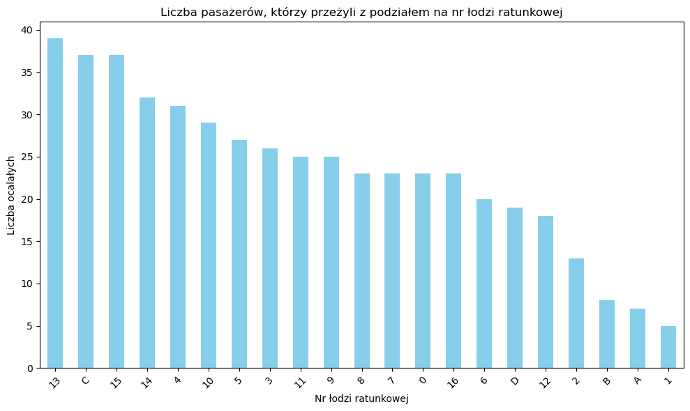

```python
# Filter out rows where 'survived' is NaN or 0 (indicating non-survivors)
survivors_df = df[df['Przeżył ?'] == 1]

# Group by 'boat' and count the number of survivors in each boat
survivors_per_boat = survivors_df.groupby('Nr łodzi ratunkowej').size()

# Sort the counts in descending order
sorted_survivors_per_boat = survivors_per_boat.sort_values(ascending=False)

# Plotting
plt.figure(figsize=(10, 6))
sorted_survivors_per_boat.plot(kind='bar', color='skyblue')
plt.title('Liczba pasażerów, którzy przeżyli z podziałem na nr łodzi ratunkowej')
plt.xlabel('Nr łodzi ratunkowej')
plt.ylabel('Liczba ocalałych')
plt.xticks(rotation=45)
plt.tight_layout()

# Save the plot as a PNG file
plot_filename = 'survivors_per_boat.png'
plt.savefig(plot_filename)
```

Mamy część danch o pasażerach i ich rozlokowaniu w łodziach ratunkowych ale z danych, które mamy łódź numer 13 była najbardziej szczęśliwą łodzią dla pasażerów.

A co z osobami, które nie przeżyły. Z których łodzi nie przeżyło najwiecej ludzi ?

```python
# Filter out rows where 'survived' is NaN and 'boat' is not NaN
df_filtered = df[df['Przeżył ?'].notna() & df['Nr łodzi ratunkowej'].notna()]

# Calculate the number of people who did not survive for each lifeboat
# Group by 'boat' and count where 'survived' is 0
non_survivors_per_boat = df_filtered[df_filtered['Przeżył ?'] == 0].groupby('Nr łodzi ratunkowej').size()

# Sort the result in descending order
non_survivors_per_boat_sorted = non_survivors_per_boat.sort_values(ascending=False)

# Declare result var
result = non_survivors_per_boat_sorted.reset_index(name='count')

print(result)
```

```
  Nr łodzi ratunkowej  count
0                   0    800
1                   A      4
2                  12      1
3                  14      1
4                   B      1
5                   C      1
6                   D      1
```

W łodzi A (w zasadzie tratwie z podnoszonymi burtami) nie przeżyło najwięcej pasażerów.

```python
typ_danych = df['Numer ciała'].dtype
print(f'Typ danych kolumny "Numer ciała": {typ_danych}')
```

```
Typ danych kolumny "Numer ciała": float64
```

```python
wycinek = df['Numer ciała']
print(wycinek)
```

```
0         NaN
1         NaN
2         NaN
3       135.0
4         NaN
        ...
1304    328.0
1305      NaN
1306    304.0
1307      NaN
1308      NaN
Name: Numer ciała, Length: 1308, dtype: float64
```

```python
pd.reset_option('display.max_rows') # Wracam do wyswietlania nie całej od
# razu df
```

```python
# Find all unique values in the "body" column
# pd.set_option('display.max_rows', None) Na chwilę chciałem przejrzeć całą kolumnę.

unique_body_values = df['Numer ciała'].unique()

# Declare result var
result = {
    "type": "dataframe",
    "value": pd.DataFrame(unique_body_values, columns=['Numer ciała']
        )
}
print(result)
```

```
{'type': 'dataframe', 'value':      Numer ciała
0            NaN
1          135.0
2           22.0
3          124.0
4          148.0
..           ...
116         14.0
117        131.0
118        312.0
119        328.0
120        304.0

[121 rows x 1 columns]}
```

```python
df['Numer ciała'] = pd.to_numeric(df['Numer ciała'], errors='coerce').fillna(0).astype(int)
print(df['Numer ciała'])
```

```
0         0
1         0
2         0
3       135
4         0
       ...
1304    328
1305      0
1306    304
1307      0
1308      0
Name: Numer ciała, Length: 1308, dtype: int32
```

Zamieniłem dane na liczby całkowite, a brak danych na 0, co ułatwi operacje na tej kolumnie.

```python
unique_body_values = df['Numer ciała'].unique()

# Declare result var
result = {
    "type": "dataframe",
    "value": pd.DataFrame(unique_body_values, columns=['Numer ciała']
        )
}
print(result)
```

```
{'type': 'dataframe', 'value':      Numer ciała
0              0
1            135
2             22
3            124
4            148
..           ...
116           14
117          131
118          312
119          328
120          304

[121 rows x 1 columns]}
```

Jakie mamy wartości w tej kolumnie ? Zobaczmy statystykę dla tej kolumny, oraz sprawdźmy jaki jest największy, a jaki najmniejszy nr ciała.

```python
filtered_df = df[(df['Numer ciała'] > 0) & (df['Numer ciała'].notna())]

# Calculate statistics for the 'body' column
body_stats = filtered_df['Numer ciała'].describe()
print(body_stats)
```

```
count    120.000000
mean     159.975000
std       97.672103
min        1.000000
25%       71.500000
50%      154.000000
75%      255.250000
max      328.000000
Name: Numer ciała, dtype: float64
```

Ciała są ponumerowane od 1 do 328. Ile mamy pustych numerów ?

```python
# Define the count of zero values in the column 'body' from 1 to 328
# 'df' represents your DataFrame
zero_count = df['Numer ciała'][1:329].apply(lambda x: x == 0).sum()
print(zero_count)
```

```
293
```

Tak duża liczba zastanawia. Chcąc się upewnić właściwego wyniku wydrukujemy brakujące wartości między 1 a 328

```python
number_set = set(range(1, 329))  # Set of numbers from 1 to 328
current_numbers = set(df['Numer ciała'])

missing_numbers = number_set - current_numbers  # Set difference to find missing numbers

# Count zeros
zero_count = df['Numer ciała'].apply(lambda x: str(x).count('0')).sum()

print('Liczba Zer:', zero_count)
print()
print('Brakujące liczby to:')
print()
print(missing_numbers)
```

```
Liczba Zer: 1211

Brakujące liczby to:

{2, 3, 5, 6, 8, 10, 11, 12, 13, 20, 21, 23, 24, 25, 26, 27, 28, 29, 30, 31, 33, 34, 36, 39, 40, 41, 42, 44, 48, 49, 54, 55, 56, 57, 59, 60, 63, 64, 65, 66, 71, 73, 74, 76, 77, 78, 82, 83, 84, 85, 86, 87, 88, 90, 91, 92, 93, 94, 95, 99, 100, 102, 104, 105, 106, 107, 111, 112, 113, 114, 115, 116, 117,…
```

W tej kolumnie brakuje najwięcej danych ze wszystkich kolumn naszego df.

Spróbujmy sprawdzić czy jakaś brakująca liczba znajduje się lub nie w kolumnie.

```python
chosen_number = 4 # insert your chosen number here
if chosen_number in df['Numer ciała'].values:
    print(f"{chosen_number} znajduje się w kolumnie 'Numer ciała'.")
else:
    print(f"{chosen_number} nie znajduje się w kolumnie 'Numer ciała'.")
```

```
4 znajduje się w kolumnie 'Numer ciała'.
```

```python
# for i in range(0, df['Numer ciała'].shape[0], 10):
#    print(df['Numer ciała'][i: i+10])
#    input("Naciśnij ENTER żeby zobaczyć kolejne 10 wierszy...")
```

[output not shown]

[output not shown]

[output not shown]

[output not shown]

[output not shown]

[output not shown]

[output not shown]

[output not shown]

[output not shown]

[output not shown]

[output not shown]

[output not shown]

[output not shown]

```python
wycinek = df['Numer ciała']
print(wycinek)
```

```
0         0
1         0
2         0
3       135
4         0
       ...
1304    328
1305      0
1306    304
1307      0
1308      0
Name: Numer ciała, Length: 1308, dtype: int32
```

Kolumna miejsce docelowe ma 369 wartości unikatowych. Poza tym ma 565 brakujących wartości. Spróbujmy dowiedzieć się jakie dane znajdują się w tej kolumnie i jak można je wykorzystać.

```python
# Get unique values from column 'place'
unique_values = df['Miejsce docelowe'].unique()

# Print the unique values
# for value in unique_values:
#    print.(value)  To drkuje cały nowy df z Mijesca docelowego
for i in range(20):
    print(unique_values[i])
```

```
St Louis, MO
Montreal, PQ / Chesterville, ON
New York, NY
Hudson, NY
Belfast, NI
Bayside, Queens, NY
Montevideo, Uruguay
Paris, France

Hessle, Yorks
Montreal, PQ
Winnipeg, MN
San Francisco, CA
Dowagiac, MI
Stockholm, Sweden / Washington, DC
Trenton, NJ
Glen Ridge, NJ
Youngstown, OH
Birkdale, England Cleveland, Ohio
London / Winnipeg, MB
```

Wiersze różnią się między sobą rodzajem informacji i zawierają:

- Miejsce początkowe
- Miejsce pośrednie
- Miejsce docelowe

Można by było jeszcze zamienić skróty miast stosowane w kolumnie na pełne nazwy. Skróty to wartości dwuliterowe. Spróbujmy je wydobyć. Następnie przetłumaczyć a potem zamienić na ich pełne nazwy.

```python
# Przyjmujemy, że 'df' to DataFrame, który zawiera kolumnę 'miejsce'
# Użyjemy 'drop_duplicates' do usunięcia duplikatów
df['Miejsce docelowe'] = df['Miejsce docelowe'].fillna('')

dwuliterowe_slowa = []

# Iterujemy po wierszach DataFrame
for i in range(len(df)):
    # Znajdujemy dwuliterowe słowa w każdym wierszu
    slowa = df['Miejsce docelowe'][i].split()
    for slowo in slowa:
        if len(slowo) == 2:
            dwuliterowe_slowa.append(slowo)

# Usuwamy duplikaty i sortujemy alfabetycznie
dwuliterowe_slowa = list(set(dwuliterowe_slowa))
dwuliterowe_slowa.sort()

# Wyświetlamy listę dwuliterowych słów
print(dwuliterowe_slowa)
```

```
['AB', 'AZ', 'BC', 'CA', 'CO', 'CT', 'Co', 'DC', 'DE', 'FL', 'IA', 'ID', 'IL', 'IN', 'KS', 'KY', 'MA', 'MB', 'ME', 'MI', 'MN', 'MO', 'MT', 'Mt', 'ND', 'NE', 'NH', 'NI', 'NJ', 'NM', 'NS', 'NY', 'OH', 'ON', 'OR', 'PA', 'PQ', 'RI', 'SD', 'SK', 'St', 'UT', 'VA', 'VT', 'WA', 'WI', 'WV', 'du', 'of', 'or']
```

Skrótów stanów(lub prowincji) jest sporo. Spróbuję rozgryźć znaczenie kilku z nich:

- MO : Missouri (USA)
- ON : Ontario (Kanada)
- NY : New York (USA)
- MN : Manitoba (Kanada)
- OH : Ohio (USA)
- CA : California (USA) Jeśli będzie to potrzebne do większej analizy, to zmienię w bazie danych skróty na pełne nazwy i stworzę dodatkową kolumnę z pełną nazwą docelową.

Można powyciągać skróty miast z wierszy i stworzyć nową kolumnę z pełną nazwą miejsca przeznaczenia pasażera. Na razie do dalszej analizy nie jest to potrzebne.

```python
'''
# Filtrujemy kolumnę "Nr łodzi ratunkowej"
mask = df['Nr łodzi ratunkowej']
mask = mask.apply(lambda x: str(x))
mask = mask.notna()  # Wykluczenie NaN
for string in ["A", "B", "C","D","1","2","3","4","5","6","7","8","9","10","11","12","13","14","15","16"]:
    mask = mask & ~df['Nr łodzi ratunkowej'].str.contains(string)

# Wyświetlenie wyników
df[mask]
'''
```

[output not shown]

```python
'''

# the input string
input_string = "Nr łodzi ratunkowej"

# find all numbers in the string
numbers = re.findall(r'\d+', input_string)

if numbers:  # check if any number found
    # convert the list of string numbers to integers
    numbers = list(map(int, numbers))

    # print the minimal and maximal number
    print('Najmniejsza liczba:', min(numbers))
    print('Największa licznba:', max(numbers))
else:
    print("No numbers found in the input string.")
'''
```

[output not shown]

```python
'''
def convert_str_to_num(df):
    """
    This function converts string numbers in the 'łódź' column of the given DataFrame into numeric data type.
    If the information in the column is not a number, it remains as a string.
    :param df: DataFrame containing the data
    :return: DataFrame after conversion
    """
    df['Nr łodzi ratunkowej'] = pd.to_numeric(df['Nr łodzi ratunkowej'], errors='ignore')
    return df
'''
```

```python
'''
# Utwórz maski dla typów danych
mask_str = df['Nr łodzi ratunkowej'].apply(lambda x: isinstance(x, str))
mask_int = df['Nr łodzi ratunkowej'].apply(lambda x: isinstance(x, int))

# Przy użyciu mask wyświetl dane
print("Dane typu str:")
print(df.loc[mask_str, 'Nr łodzi ratunkowej'])

print("\nDane typu int:")
print(df.loc[mask_int, 'Nr łodzi ratunkowej'])
'''
```

[output not shown]

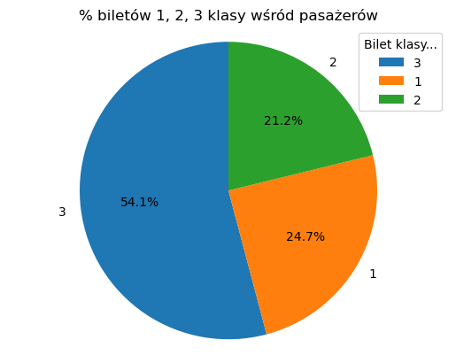

```python
# Odfiltowujemy te wiersze, które mają wartość NaN lub 0
# bo będą nam psuły wykres. Ich ilość jest znikoma więc ogólnie
# można ją pominąć
filtered_df = df[df['Klasa biletu'].notna() & (df['Klasa biletu'] != 0)]

# Calculate the percentage of each class
class_counts = filtered_df['Klasa biletu'].value_counts(normalize=True) * 100

# Rysujemy wykres
fig, ax = plt.subplots()
ax.pie(class_counts, labels=class_counts.index, autopct='%1.1f%%', startangle=90)
ax.axis('equal')  # Equal aspect ratio ensures that pie is drawn as a circle.
plt.legend(title="Bilet klasy...")
plt.title("% biletów 1, 2, 3 klasy wśród pasażerów")

# Save the plot as a PNG file
plt.savefig("ticket_class_distribution.png")
```

Widać duży kontrast w klasie kupionych biletów. Bilety najdroższe przewyższyły ilością te z drugiej klasy. Sprawdzimy przeciętną cenę biletu, żeby sprawdzić czy bilety były tak drogie, że większość pasażerów kupowała bilet trzeciej klasy.

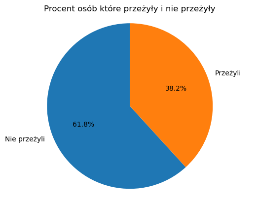

```python
df_cleaned = df.dropna(subset=['Przeżył ?'])

# Calculate the percentage of survivors and non-survivors
survival_counts = df_cleaned['Przeżył ?'].value_counts(normalize=True) * 100

# Plot a pie chart
fig, ax = plt.subplots()
ax.pie(survival_counts, labels=['Nie przeżyli', 'Przeżyli'], autopct='%1.1f%%', startangle=90)
ax.axis('equal')  # Equal aspect ratio ensures that pie is drawn as a circle.
plt.title('Procent osób które przeżyły i nie przeżyły')

# Save the plot as a PNG file
plot_filename = "survival_pie_chart.png"
plt.savefig(plot_filename)
```

Jest to procent osób których analizujemy dane. Nie mylić z ogólnymi danymi wszystkich osób, które były na statku w momencie katastrofy.

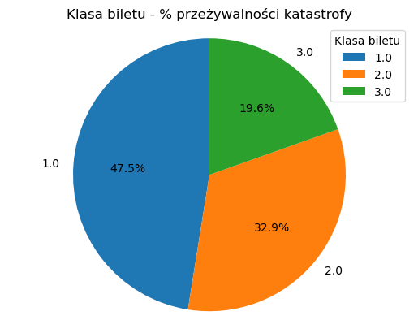

```python
# Filter out rows with NaN values in 'pclass' and 'survived'
df = df.dropna(subset=['Klasa biletu', 'Przeżył ?'])

# Calculate the percentage of survivors for each class
survival_rates = df[df['Przeżył ?'] == 1].groupby('Klasa biletu').size() / df.groupby('Klasa biletu').size() * 100

# Plotting
fig, ax = plt.subplots()
ax.pie(survival_rates, labels=survival_rates.index, autopct='%1.1f%%', startangle=90)
ax.set_title('Klasa biletu - % przeżywalności katastrofy')
plt.legend(title="Klasa biletu")
plt.axis('equal')  # Equal aspect ratio ensures that pie is drawn as a circle.

# Save the plot as a PNG file
plt.savefig("survival_by_class.png")
```

Widzimy wyraźny związek między klasą biletu a przeżywalnością. Im lepsza klasa biletu tym większa przeżywalność. Czy chodziło o odległość kabin ludzi z pierwszych klas do szalup ratunkowych ?

A co z związkiem z miejscem wejścia na pokład i przeżywalnością katastrofy ?

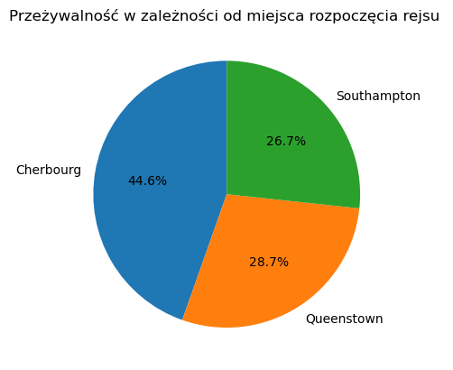

```python
# Map the embarked codes to full port names
port_names = {'C': 'Cherbourg', 'Q': 'Queenstown', 'S': 'Southampton'}
df['Port wejścia pasażera'] = df['Port wejścia pasażera'].map(port_names)

# Calculate survival rates based on embarkation point
embark_survival = df.groupby('Port wejścia pasażera')['Przeżył ?'].mean() * 100

# Plot a pie chart
fig, ax = plt.subplots()
ax.pie(embark_survival, labels=embark_survival.index, autopct='%1.1f%%', startangle=90)
ax.set_title('Przeżywalność w zależności od miejsca rozpoczęcia rejsu ')

# Save the plot as a PNG file
plt.savefig('survival_rate_pie_chart.png')
```

Cherbourg - jako miejsce wejście pasażera "dawała" największe szanse na przeżycie.

Czym pasażerowie tych trzech portów różnili się od siebie ? Sprawdźmy ile średnio kosztował bilet w przeliczeniu na jednego pasażera wsiadającego w tych trzech portach.

[figure not shown]

```python
# Filter out rows with missing 'embarked' or 'fare' values
df = df.dropna(subset=['Port wejścia pasażera', 'Cena biletu'])

# Calculate the total fare and number of passengers for each port
port_data = df.groupby('Port wejścia pasażera').agg({'Cena biletu': 'sum', 'Imię i nazwisko': 'count'}).reset_index()
port_data.columns = ['Port', 'Total Fare', 'Passenger Count']

# Calculate the fare per passenger for each port
port_data['Fare per Passenger'] = port_data['Total Fare'] / port_data['Passenger Count']

# Map port codes to names
port_names = {'S': 'Southampton', 'C': 'Cherbourg', 'Q': 'Queenstown'}
port_data['Port Name'] = port_data['Port'].map(port_names)

# Plotting
fig, ax = plt.subplots(figsize=(10, 6))
bars = ax.bar(port_data['Port Name'], port_data['Fare per Passenger'], color=['blue', 'green', 'red'])

# Add passenger count on top of each bar
for bar, passenger_count in zip(bars, port_data['Passenger Count']):
    yval = bar.get_height()
    ax.text(bar.get_x() + bar.get_width()/2, yval, f'{passenger_count}', va='bottom', ha='center', color='white')

# Add legend (poprawiony kod)
handles = [bar for bar in bars]  # Pobierz uchwyty słupków
legend_labels = [f"{row['Port Name']}: {row['Passenger Count']} passengers" for index, row in port_data.iterrows()]
ax.legend(handles, legend_labels, title="Passenger Count", loc='upper right')
# Set labels and title
ax.set_ylabel('Fare per Passenger')
ax.set_title('Fare per Passenger by Port of Embarkation')

# Save the plot as a PNG file
plt.tight_layout()
plt.savefig("fare_per_passenger_chart.png")
```

Pasażerowie wsiadający w Cherbourg kupowali najdroższe bilety (średnia w przeliczeniu na jednego pasażera), a pasażerowie Queenstown kupowali najtańsze.

Nie wiem, czy możemy obliczać w oparciu o dane z kolumny Nr łodzi ratunkowej, skoro brakuje tam 62,9% danych. Zobaczmy mimo to jak mając takie dane wyglądało zapełnienie łodzi ratunkowych...

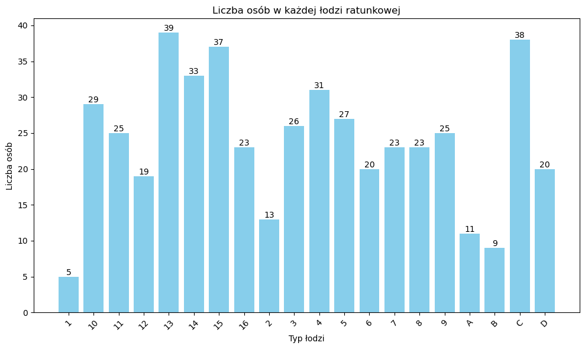

```python
# Usuń wiersze z NaN w kolumnie 'Nr łodzi ratunkowej'
df_boat = df.dropna(subset=['Nr łodzi ratunkowej'])

# Stwórz kopię DataFrame
df_boat = df_boat.copy()

# Konwertuj kolumnę 'Nr łodzi ratunkowej' na liczby całkowite
df_boat = df_boat.assign(Nr_łodzi_ratunkowej=pd.to_numeric(df_boat['Nr łodzi ratunkowej'], errors='coerce'))

# Usuń wiersze, gdzie 'Nr łodzi ratunkowej' jest równy 0
df_boat = df_boat.loc[df_boat['Nr łodzi ratunkowej'] != 0]

# Utwórz nową kolumnę 'Typ łodzi'
df_boat = df_boat.assign(Typ_łodzi=df_boat['Nr łodzi ratunkowej'].fillna('Litera'))

# Zastąp wartości liczbowe w kolumnie 'Typ łodzi' nazwami łodzi
df_boat.loc[:, 'Typ_łodzi'] = df_boat['Typ_łodzi'].apply(lambda x: str(x) if isinstance(x, int) else x)

# Usuń wiersze, gdzie 'Typ łodzi' jest równy 'Litera'
df_boat = df_boat.loc[df_boat['Typ_łodzi'] != 'Litera']

# Upewnij się, że wszystkie wartości są typu string
df_boat['Typ_łodzi'] = df_boat['Typ_łodzi'].astype(str)

# Policz liczbę osób w każdej łodzi
boat_counts = df_boat['Typ_łodzi'].value_counts().sort_index()

# Narysuj wykres
plt.figure(figsize=(10, 6))
bars = plt.bar(boat_counts.index, boat_counts.values, color='skyblue')

# Dodaj liczby na górze każdego słupka
for bar in bars:
    yval = bar.get_height()
    plt.text(bar.get_x() + bar.get_width()/2, yval, int(yval), va='bottom', ha='center')

plt.xlabel('Typ łodzi')
plt.ylabel('Liczba osób')
plt.title('Liczba osób w każdej łodzi ratunkowej')
plt.xticks(rotation=45)
plt.tight_layout()

# Zapisz wykres jako plik PNG
plt.savefig('lifeboat_counts.png')

plt.show()  # Wyświetl wykres
```

Tak wyglądało zapełnienie łodzi w oparciu o nasze niekompletne dane. Szczególnie brak danych widać w łodzi nr. 1 gdzie dane mamy tylko pięciu pasażerów. Do każdej łodzi (nie tratwy z podnoszonymi burtami) mogło wsiąść maksymalnie 65 osób. Widzimy więc jak dużo danych nam brakuje.

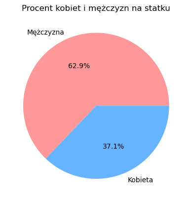

```python
gender_counts = df['Płeć'].value_counts(normalize=True) * 100

# Plotting
fig, ax = plt.subplots()
ax.pie(gender_counts, labels=gender_counts.index, autopct='%1.1f%%', colors=['#ff9999','#66b3ff'])
ax.set_title('Procent kobiet i mężczyzn na statku')

# Save the plot as a PNG file
plt.savefig("gender_distribution_pie_chart.png")
```

Jak widzimy mężczyzn było na statku znacznie wiecej od kobiet. A jak to wyglądało w podziale na wiek i ilość pasażerów ?

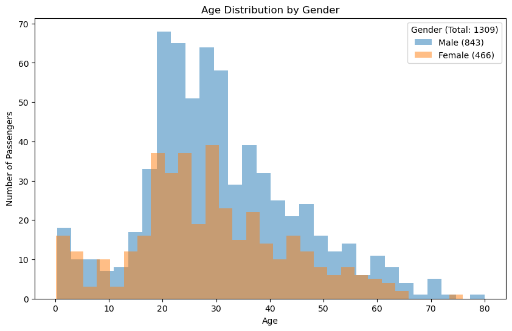

```python
# Count the number of males and females
male_count = df[df['Płeć'] == 'Mężczyzna'].shape[0]
female_count = df[df['Płeć'] == 'Kobieta'].shape[0]

# Plotting the age distribution by gender
plt.figure(figsize=(10, 6))
for gender in ['Mężczyzna', 'Kobieta']:
    subset = df[df['Płeć'] == gender]
    plt.hist(subset['Wiek'].dropna(), bins=30, alpha=0.5, label=f"{gender.capitalize()}")

# Add legend with the count of males and females
plt.legend(title=f"Gender (Total: {male_count + female_count})", labels=[f"Male ({male_count})", f"Female ({female_count})"])
plt.title('Age Distribution by Gender')
plt.xlabel('Age')
plt.ylabel('Number of Passengers')

# Save the plot as a PNG file
plt.savefig("age_gender_distribution.png")
```

Meżczyzn było znacznie więcej niż kobiet na statku. Największe różnice w ilościach są w zakresie 20-25 lat. Wraca pytanie czy panowie w tym wieku - to mogli być emigranci ?

A jak wyglądał przedział wieku w poszczególnych klasach ?

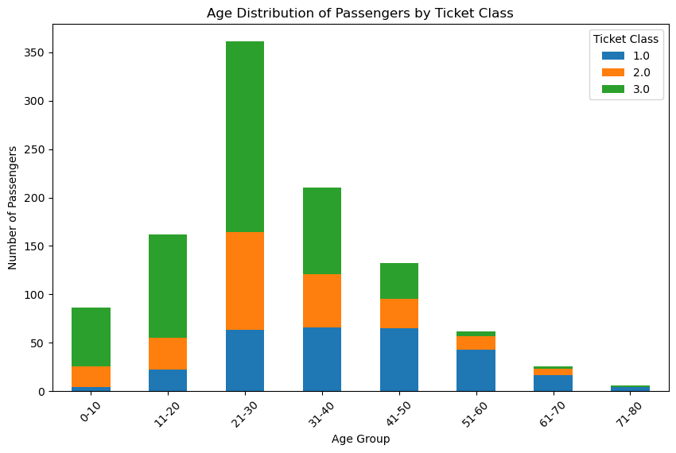

```python
# Drop rows with NaN values in 'age' or 'pclass'
df = df.dropna(subset=['Wiek', 'Klasa biletu'])

# Define age bins and labels
age_bins = [0, 10, 20, 30, 40, 50, 60, 70, 80]
age_labels = ['0-10', '11-20', '21-30', '31-40', '41-50', '51-60', '61-70', '71-80']

# Create a new column for age groups
df['age_group'] = pd.cut(df['Wiek'], bins=age_bins, labels=age_labels)

# Group by age group and class
age_class_group = df.groupby(['age_group', 'Klasa biletu']).size().unstack()

# Plot the data
age_class_group.plot(kind='bar', stacked=True, figsize=(10, 6))
plt.title('Age Distribution of Passengers by Ticket Class')
plt.xlabel('Age Group')
plt.ylabel('Number of Passengers')
plt.xticks(rotation=45)
plt.legend(title='Ticket Class', loc='upper right')

# Save the plot as a PNG file
plt.savefig('age_distribution_by_class.png')
```

Ciekawie wyglądają proporcje w kupowanych biletach w poszczególnych grupach wiekowych. I tak klasa trzecia dominuje w ilość od 1 do 40 lat. Klasa pierwsza zaczyna przeważać dopiero od pasażerów w wieku 41lat w zwyż. Klasa druga liczy się w pierwszej grupie do 10 lat jak i od 51 lat w zwyż. Osoby starsze wybierały wygodę pierwszej klasy i były je na to stać. Widzimy też jaką liczną grupę klasy trzeciej stanowiły dzieci i osoby młodociane.

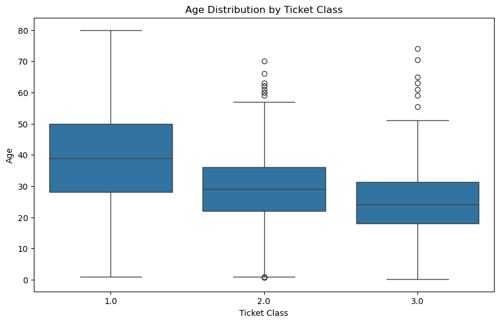

```python
# Filter out rows where 'pclass' or 'age' is NaN
df_filtered = df.dropna(subset=['Klasa biletu', 'Wiek'])

# Create a boxplot for age distribution across different ticket classes
plt.figure(figsize=(10, 6))
sns.boxplot(x='Klasa biletu', y='Wiek', data=df_filtered)
plt.title('Age Distribution by Ticket Class')
plt.xlabel('Ticket Class')
plt.ylabel('Age')

# Save the plot as a PNG file
plt.savefig('boxplot_ticket_class_age.png')
```

Na boxplotach od razu widać średną wieku która rośnie wraz z droższą klasą biletu. Widać też pojedynczych nieszczęśników którzy mimo słusznego już wieku spędzało podróż w klasie trzeciej. Ciekawe czy mimo męczącej podróży w klasie trzeciej udało im się przeżyć ? Spradźmy....

```python
# Filter the data for third class passengers
third_class_passengers = df[df['Klasa biletu'] == 3]

# Calculate the IQR to find outliers
Q1 = third_class_passengers['Wiek'].quantile(0.25)
Q3 = third_class_passengers['Wiek'].quantile(0.75)
IQR = Q3 - Q1

# Determine outliers
outliers = third_class_passengers[(third_class_passengers['Wiek'] < (Q1 - 1.5 * IQR)) | (third_class_passengers['Wiek'] > (Q3 + 1.5 * IQR))]

# Tworzymy HTML z tabelą
html_table = outliers.to_html(index=False)

# Wyświetlamy tabelę z paskiem przewijania
display(HTML(f'<div style="overflow-x: auto;">{html_table}</div>'))
```

| Klasa biletu | Przeżył ? | Imię i nazwisko | Płeć | Wiek | Ilość-rodzeństwo/małżonek | Ilość-rodziców/dzieci | Numer biletu | Cena biletu | Numer kabiny | Port wejścia pasażera | Nr łodzi ratunkowej | Numer ciała | Miejsce docelowe | age_group |
| --- | --- | --- | --- | --- | --- | --- | --- | --- | --- | --- | --- | --- | --- | --- |
| 3.0 | Nie | Connors, Mr. Patrick | Mężczyzna | 70.5 | 0 | 0.0 | 370369 | 7.75 | NaN | Q | 0 | 171.0 |  | 71-80 |
| 3.0 | Nie | Coxon, Mr. Daniel | Mężczyzna | 59.0 | 0 | 0.0 | 364500 | 7.25 | NaN | S | 0 | 0.0 | Merrill, WI | 51-60 |
| 3.0 | Nie | Duane, Mr. Frank | Mężczyzna | 65.0 | 0 | 0.0 | 336439 | 7.75 | NaN | Q | 0 | 0.0 |  | 61-70 |
| 3.0 | Nie | Meo, Mr. Alfonzo | Mężczyzna | 55.5 | 0 | 0.0 | A.5. 11206 | 8.05 | NaN | S | 0 | 201.0 |  | 51-60 |
| 3.0 | Nie | Nysveen, Mr. Johan Hansen | Mężczyzna | 61.0 | 0 | 0.0 | 345364 | 6.24 | NaN | S | 0 | 0.0 |  | 61-70 |
| 3.0 | Nie | Svensson, Mr. Johan | Mężczyzna | 74.0 | 0 | 0.0 | 347060 | 7.78 | NaN | S | 0 | 0.0 |  | 71-80 |
| 3.0 | Tak | Turkula, Mrs. (Hedwig) | Kobieta | 63.0 | 0 | 0.0 | 4134 | 9.59 | NaN | S | 15 | 0.0 |  | 61-70 |

Z najstarszych 7 pasażerów trzeciej klasy tylko jedna pasażerka (Turkula, Mrs. (Hedwig) przeżyła katastrofę. Co ciekawe, była jedyną kobietą z tej siódemki outliers-ów.

[figure not shown]

```python
survived_by_gender = df.groupby('Płeć')['Przeżył ?'].mean() * 100

# Plotting
fig, ax = plt.subplots()
ax.pie(survived_by_gender, labels=survived_by_gender.index, autopct='%1.1f%%', startangle=90, colors=['#ff9999','#66b3ff'])
ax.axis('equal')  # Equal aspect ratio ensures that pie is drawn as a circle.
plt.title('Percentage of Survivors by Gender')

# Save the plot as a PNG file
plt.savefig("survivors_by_gender.png")
```

Jak widzimy dużą większą przeżywalność miały kobiety niż mężczyźni. Czy wynika to z tego, że Panie były przepuszczane pierwsze do łodzi ratunkowych ?

A co z przeżywalnością w stosunku do wieku pasażera ?

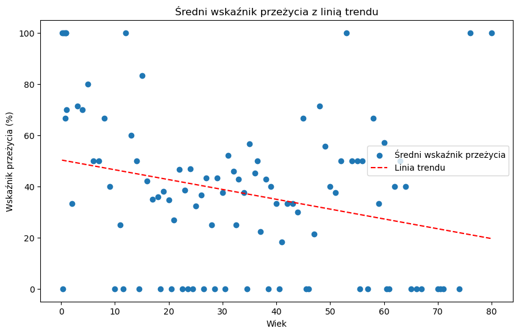

```python
age_survival = df.groupby('Wiek')['Przeżył ?'].mean()
plt.figure(figsize=(10, 6))
plt.scatter(age_survival.index, age_survival.values * 100, label='Średni wskaźnik przeżycia')

# Remove NaN values for fitting the trend line
valid_indices = age_survival.index[~np.isnan(age_survival.index)]
valid_values = age_survival.values[~np.isnan(age_survival.index)]

z = np.polyfit(valid_indices, valid_values * 100, 1)
p = np.poly1d(z)
plt.plot(valid_indices, p(valid_indices), 'r--', label='Linia trendu')

plt.ylim(-5, 105)
plt.xlabel('Wiek')
plt.ylabel('Wskaźnik przeżycia (%)')
plt.title('Średni wskaźnik przeżycia z linią trendu')
plt.legend()
# Save the plot as a PNG file
plt.savefig("Sredni wskaźnik przeżycia.png")
```

Przeżywalność ogólnie malała wraz z wzrostem wieku. Można powiedzieć - "Lepiej było być młodym i żywym". Wykres ten nie pokazuje ilości wystąpień co może być mylące i zmuszające nas do "zawierzenia" wygenerowanej linii trendu. Poprawmy zatem ten wykres...

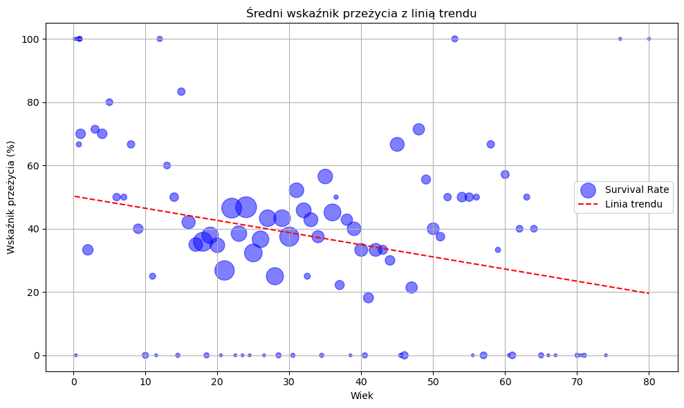

```python
# Drop rows with missing 'age' or 'survived' values
df = df.dropna(subset=['Wiek', 'Przeżył ?'])

# Calculate average survival rate and count for each age
age_survival = df.groupby('Wiek').agg({'Przeżył ?': 'mean', 'Wiek': 'size'}).rename(columns={'Wiek': 'count'})

# Plot
plt.figure(figsize=(10, 6))
scatter = plt.scatter(age_survival.index, age_survival['Przeżył ?'] * 100, s=age_survival['count']*10, alpha=0.5, c='b', label='Survival Rate')

# Add trend line
z = np.polyfit(age_survival.index, age_survival['Przeżył ?'] * 100, 1)
p = np.poly1d(z)
plt.plot(age_survival.index, p(age_survival.index), "r--", label='Linia trendu')

# Set labels and title
plt.xlabel('Wiek')
plt.ylabel('Wskaźnik przeżycia (%)')
plt.title('Średni wskaźnik przeżycia z linią trendu')
plt.ylim(-5, 105)

# Add legend for size
handles, labels = scatter.legend_elements(prop="sizes", alpha=0.6)
legend2 = plt.legend(handles, labels, loc="upper right", title="Number of Occurrences")

# Show plot
plt.legend()
plt.grid(True)
plt.tight_layout()

# Save plot as a PNG file
plt.savefig("survival_rate_by_age.png")
```

Na poprawionym wykresie widać sporo przypadków ludzi powyżej 45roku życia których wskaźnik przeżycia wynosił ponad 40% nie jest to może ogólnie dużo ale linia trendu przy tym wieku jest na poziomie 25% przeżywalności. I jest to zastanawiająca różnica. Patrząc na wykres chciałoby się by linia trendu w tym właśnie miejscu powinna zmienić trend. Ciekawe dlaczego wykres tego nie pokazuje ?

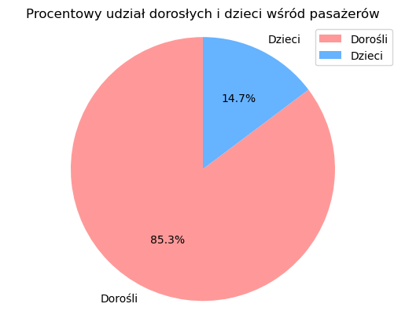

```python
df = df

age_threshold = 18

# Calculate the number of adults and children
adults_count = df[df['Wiek'] >= age_threshold].shape[0]
children_count = df[df['Wiek'] < age_threshold].shape[0]

# Calculate percentages
total_passengers = adults_count + children_count
adults_percentage = (adults_count / total_passengers) * 100
children_percentage = (children_count / total_passengers) * 100

# Plotting
labels = ['Dorośli', 'Dzieci']
sizes = [adults_percentage, children_percentage]
colors = ['#ff9999','#66b3ff']

fig1, ax1 = plt.subplots()
ax1.pie(sizes, colors=colors, labels=labels, autopct='%1.1f%%', startangle=90)
ax1.axis('equal')  # Equal aspect ratio ensures that pie is drawn as a circle.
plt.legend(labels, loc="best")
plt.title('Procentowy udział dorosłych i dzieci wśród pasażerów')

# Save the plot as a PNG file
plt.savefig("passenger_age_distribution.png")
```

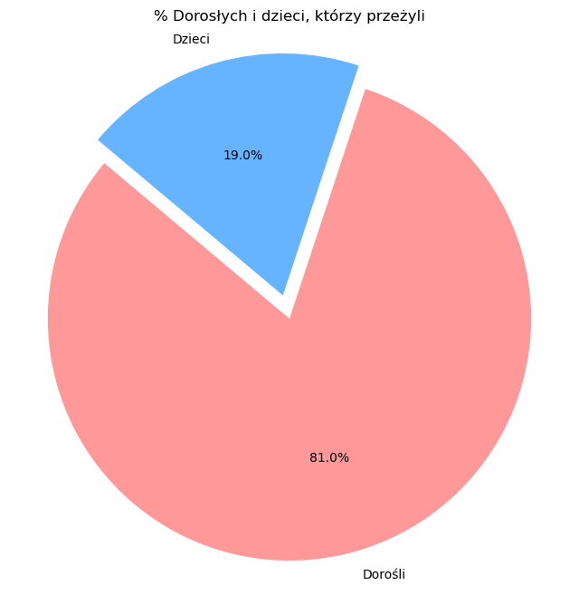

```python
survived_df = df[df['Przeżył ?'] == 1]

# Define age threshold for adults (e.g., 18 years)
age_threshold = 18

# Calculate the number of adults and children who survived
adults_survived = survived_df[survived_df['Wiek'] >= age_threshold].shape[0]
children_survived = survived_df[survived_df['Wiek'] < age_threshold].shape[0]

# Calculate percentages
total_survived = adults_survived + children_survived
adults_percentage = (adults_survived / total_survived) * 100
children_percentage = (children_survived / total_survived) * 100

# Plotting
labels = ['Dorośli', 'Dzieci']
sizes = [adults_percentage, children_percentage]
colors = ['#ff9999','#66b3ff']
explode = (0.1, 0)  # explode the first slice

plt.figure(figsize=(8, 8))
plt.pie(sizes, explode=explode, labels=labels, colors=colors, autopct='%1.1f%%', startangle=140)
plt.axis('equal')  # Equal aspect ratio ensures that pie is drawn as a circle.
plt.title('% Dorosłych i dzieci, którzy przeżyli')
plt.savefig("survival_pie_chart.png")
```

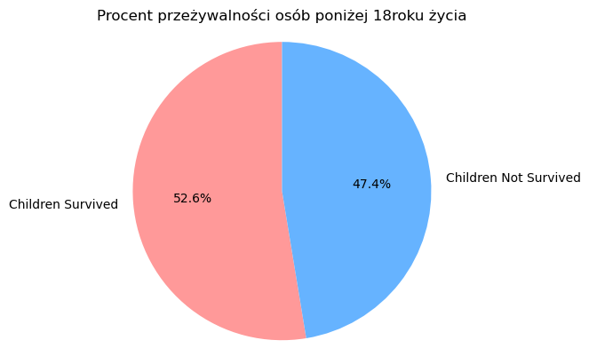

```python
children = df[df['Wiek'] < 18]

# Calculate the number of children who survived
children_survived = children[children['Przeżył ?'] == 1]

# Calculate percentages
total_children = len(children)
total_children_survived = len(children_survived)

percent_children_survived = (total_children_survived / total_children) * 100 if total_children > 0 else 0
percent_children_not_survived = 100 - percent_children_survived

# Plotting
labels = ['Children Survived', 'Children Not Survived']
sizes = [percent_children_survived, percent_children_not_survived]
colors = ['#ff9999','#66b3ff']

fig1, ax1 = plt.subplots()
ax1.pie(sizes, labels=labels, colors=colors, autopct='%1.1f%%', startangle=90)
ax1.axis('equal')  # Equal aspect ratio ensures that pie is drawn as a circle.

# Save the plot as a PNG file
plt.title('Procent przeżywalności osób poniżej 18roku życia')
plt.savefig("children_survival_pie_chart.png")
```

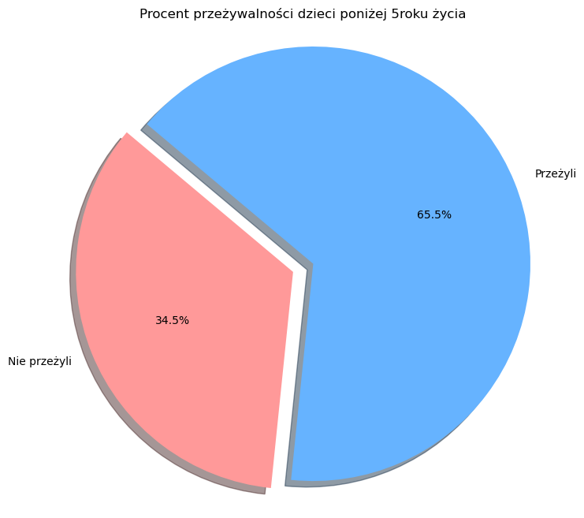

```python
young_children = df[df['Wiek'] <= 5]

# Calculate the number of survivors and non-survivors among young children
survived_count = young_children[young_children['Wiek'] == 1].shape[0]
not_survived_count = young_children[young_children['Przeżył ?'] == 0].shape[0]

# Calculate percentages
total_young_children = survived_count + not_survived_count
survived_percentage = (survived_count / total_young_children) * 100
not_survived_percentage = (not_survived_count / total_young_children) * 100

# Plotting
labels = ['Nie przeżyli', 'Przeżyli']
sizes = [survived_percentage, not_survived_percentage]
colors = ['#ff9999','#66b3ff']
explode = (0.1, 0)  # explode the 1st slice

plt.figure(figsize=(8, 8))
plt.pie(sizes, explode=explode, labels=labels, colors=colors, autopct='%1.1f%%', shadow=True, startangle=140)
plt.axis('equal')  # Equal aspect ratio ensures that pie is drawn as a circle.

# Save the plot as a PNG file
plt.title('Procent przeżywalności dzieci poniżej 5roku życia')
plt.savefig("young_children_survival.png")
```

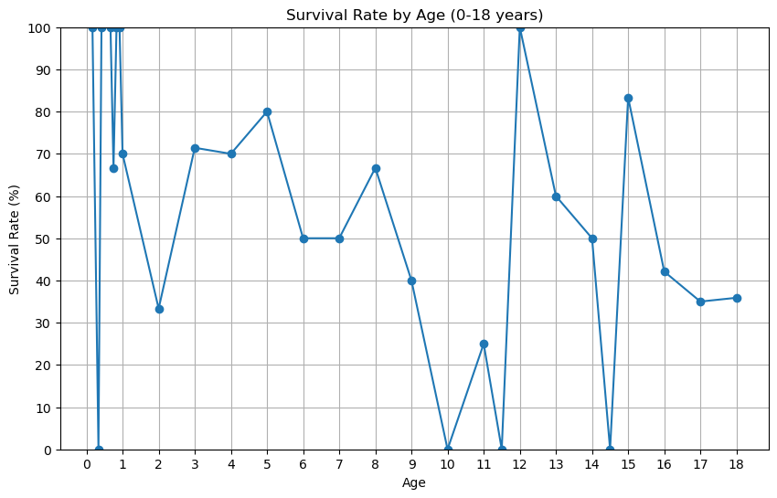

```python
children_df = df[(df['Wiek'] >= 0) & (df['Wiek'] <= 18)]

# Calculate survival rate by age
survival_rate_by_age = children_df.groupby('Wiek')['Przeżył ?'].mean() * 100

# Plotting
plt.figure(figsize=(10, 6))
plt.plot(survival_rate_by_age.index, survival_rate_by_age.values, marker='o', linestyle='-')
plt.title('Survival Rate by Age (0-18 years)')
plt.xlabel('Age')
plt.ylabel('Survival Rate (%)')
plt.ylim(0, 100)
plt.grid(True)
plt.xticks(range(0, 19))
plt.yticks(range(0, 101, 10))

# Save the plot as a PNG file
plt.savefig('survival_rate_by_age.png')
```

Zależność wieku od przeżywalnośći. Zakres od 0 do 18lat. Nie potwierdza się hipoteza że im starsze dziecko tym przeżywalność jest mniejsza. Sprawdzimy te dane w odniesieniu do ilośći wystąpień.

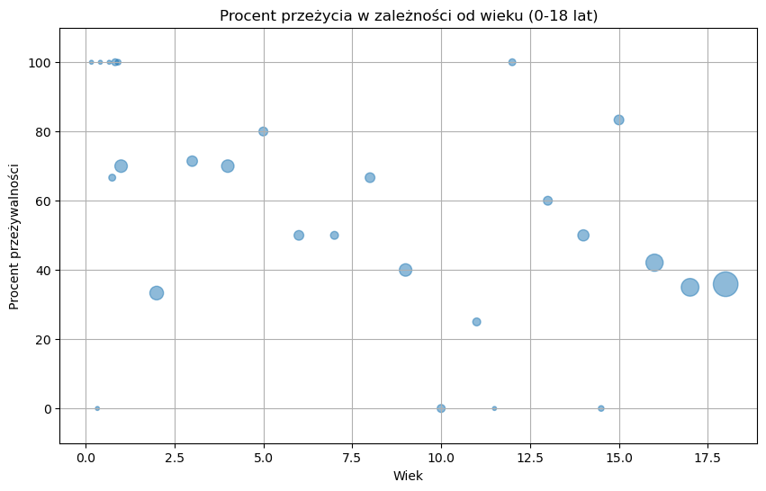

```python
age_filtered_df = df[(df['Wiek'] >= 0) & (df['Wiek'] <= 18)]
survival_by_age = age_filtered_df.groupby('Wiek')['Przeżył ?'].mean() * 100

# Calculate the number of passengers by age
count_by_age = age_filtered_df['Wiek'].value_counts().sort_index()

# Plotting
plt.figure(figsize=(10, 6))
plt.scatter(survival_by_age.index, survival_by_age.values, s=count_by_age.values*10, alpha=0.5)
plt.title('Procent przeżycia w zależności od wieku (0-18 lat)')
plt.xlabel('Wiek')
plt.ylabel('Procent przeżywalności')
plt.ylim(-10, 110)  # Set y-axis from -10% to 110%
plt.grid(True)

# Save the plot as a PNG file
plot_filename = "survival_rate_by_age.png"
plt.savefig(plot_filename)
```

Liczba występowań - jest reprezentowana przez wielkość kul.

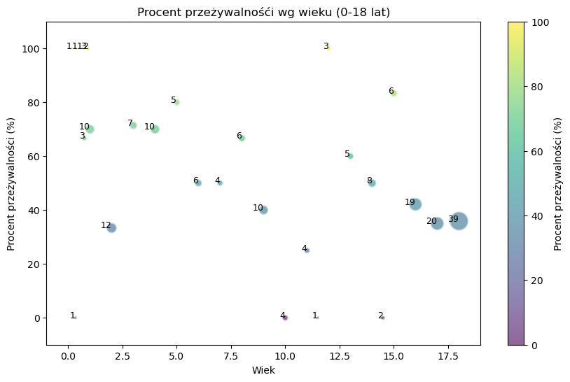

```python
age_filtered_df = df[(df['Wiek'] >= 0) & (df['Wiek'] <= 18)]

# Calculate survival percentage by age
survival_by_age = age_filtered_df.groupby('Wiek')['Przeżył ?'].mean() * 100

# Calculate the number of occurrences by age
occurrences_by_age = age_filtered_df['Wiek'].value_counts().sort_index()

# Plotting
fig, ax = plt.subplots(figsize=(10, 6))

# Scatter plot with bubble size representing occurrences and color intensity representing survival rate
scatter = ax.scatter(
    survival_by_age.index,
    survival_by_age.values,
    s=occurrences_by_age.values * 10,  # Bubble size
    c=survival_by_age.values,  # Color intensity
    cmap='viridis',
    alpha=0.6,
    edgecolors="w",
    linewidth=2
)

# Add color bar
cbar = plt.colorbar(scatter)
cbar.set_label('Procent przeżywalności (%)')

# Add labels for each point
for i, txt in enumerate(occurrences_by_age):
    ax.annotate(f'{txt}', (survival_by_age.index[i], survival_by_age.values[i]), fontsize=9, ha='right')

# Set axis limits
ax.set_xlim(-1, 19)
ax.set_ylim(-10, 110)

# Add labels and title
ax.set_xlabel('Wiek')
ax.set_ylabel('Procent przeżywalności (%)')
ax.set_title('Procent przeżywalnośći wg wieku (0-18 lat)')

# Save the plot
plt.savefig("survival_rate_by_age.png")
```

Ilość występowania przypadku połączony z wiekiem i % przeżywalności katastrofy. Nie wyłania się jakiś jeden wzorzec jeśli chodzi o przeżywalność dzieci, czy młodocianych.

```python
top_10_ages = df.sort_values(by='Wiek', ascending=False).head(10)

# Select only the 'age' column from the sorted DataFrame
top_10_ages_column = top_10_ages[['Wiek']]

# Declare result variable
result = {
    "type": "dataframe",
    "value": top_10_ages_column
}
print(top_10_ages_column)
```

```
      Wiek
14    80.0
61    76.0
1235  74.0
135   71.0
9     71.0
727   70.5
81    70.0
506   70.0
285   67.0
594   66.0
```

Widzimy, że najstarszym pasażerem był 80-latek. Widać również jak przez 10 kolejnych pasażerów wiek zmalał aż 14 lat. Niewielki odsetek jest pasażerów w przedziale 66-80 lat. Dlaczego wśród babć i dziadków Tytanic nie cieszył się popularnością ?

```python
down_10_ages = df.sort_values(by='Wiek', ascending=True).head(10)

# Select only the 'age' column from the sorted DataFrame
down_10_ages_column = down_10_ages[['Wiek']]

# Declare result variable
result = {
    "type": "dataframe",
    "value": down_10_ages_column
}
print(down_10_ages_column)
```

```
        Wiek
763   0.1667
747   0.3333
1240  0.4167
427   0.6667
1111  0.7500
657   0.7500
658   0.7500
359   0.8333
611   0.8333
548   0.8333
```

Pierwsza dziesiątka najmłodszych pasażerów to dzieci poniżej 1 roku życia. Sprawdźmy ile w sumie było dzieci do 1 roku włącznie i jaki to był procent wszystkich pasażerów.

```python
children_under_one = df[df['Wiek'] <= 1].shape[0]
print(children_under_one)
```

```
22
```

Dzieci w wieku 1rok i mniej było 22

```python
total_passengers = len(df)
children_under_1 = df[df['Wiek'] <= 1].shape[0]
percentage_children_under_1 = (children_under_1 / total_passengers) * 100
rounded_percentage = round(percentage_children_under_1, 2)
print(rounded_percentage)
```

[output not shown]

Dzieci poniżej jednego roku włącznie stanowiły zaledwie 1,68 procent załogi.

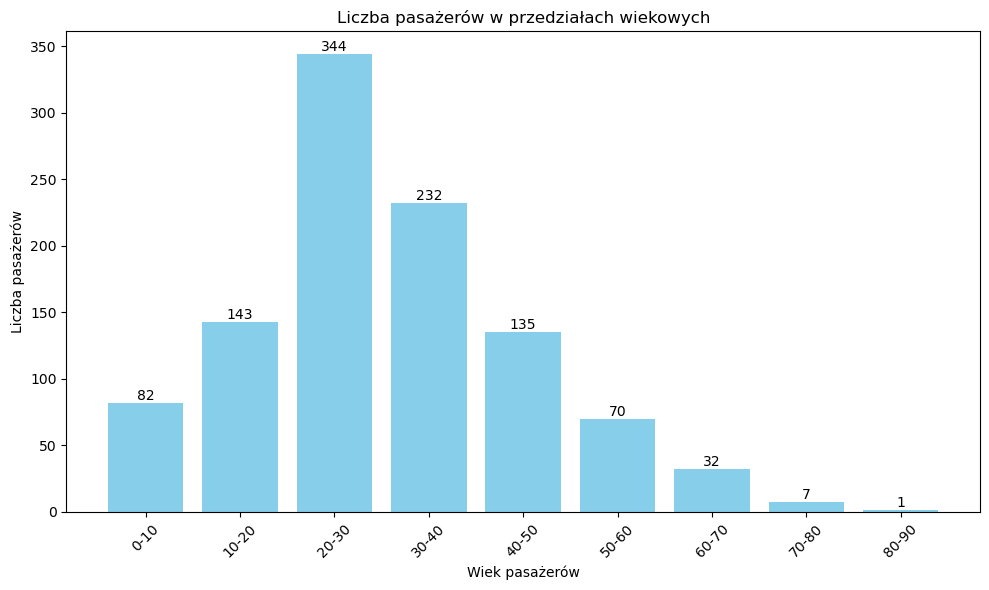

```python
df = df.dropna(subset=['Wiek'])

# Define age bins and labels
bins = [0, 10, 20, 30, 40, 50, 60, 70, 80, 90]
labels = ['0-10', '10-20', '20-30', '30-40', '40-50', '50-60', '60-70', '70-80', '80-90']

# Create a new column 'age_group' with the defined bins
df.loc['age_group'] = pd.cut(df['Wiek'], bins=bins, labels=labels, right=False)

# Count the number of passengers in each age group
age_group_counts = df['age_group'].value_counts().sort_index()

# Plotting
plt.figure(figsize=(10, 6))
bars = plt.bar(age_group_counts.index, age_group_counts.values, color='skyblue')

# Add text annotations above the bars
for bar in bars:
    yval = bar.get_height()
    plt.text(bar.get_x() + bar.get_width()/2, yval, int(yval), va='bottom', ha='center')

plt.xlabel('Wiek pasażerów')
plt.ylabel('Liczba pasażerów')
plt.title('Liczba pasażerów w przedziałach wiekowych')
plt.xticks(rotation=45)
plt.tight_layout()

# Save the plot as a PNG file
plt.savefig('age_distribution.png')
```

Rozkład wieku pasażerów wg grup zakresu 10lat. Dominują 20-30 latkowie, a następnie 30-40latkowie. Można spróbować zrobić jeszcze dokładniejszy rozkład wieku pasażerów z podziałem 1roku Zobaczmy...

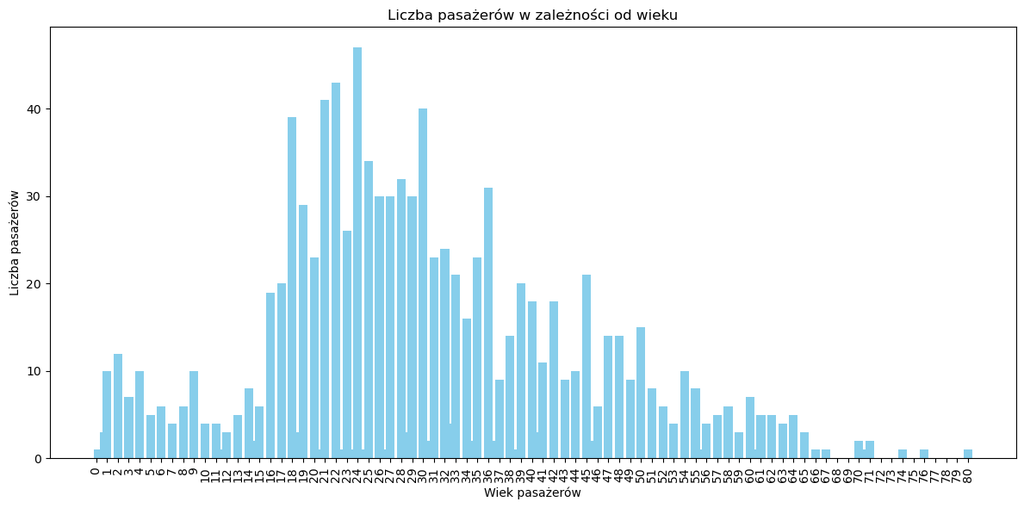

```python
df_age = df.dropna(subset=['Wiek'])

# Count the number of passengers for each age
age_counts = df_age['Wiek'].value_counts().sort_index()

# Plotting
plt.figure(figsize=(12, 6))
plt.bar(age_counts.index, age_counts.values, color='skyblue')
plt.xlabel('Wiek pasażerów')
plt.ylabel('Liczba pasażerów')
plt.title('Liczba pasażerów w zależności od wieku')
plt.xticks(range(int(df_age['Wiek'].min()), int(df_age['Wiek'].max()) + 1, 1), rotation=90)
plt.tight_layout()

# Save the plot as a PNG file
plt.savefig('age_distribution.png')
```

Wykres jest dokładny ale nie tworzy łatwego do interpretacji opisu danych.

Zmniejszmy nieco dokładność i stwórzmy przedziały wiekowe zaokrąglone do 2lat.

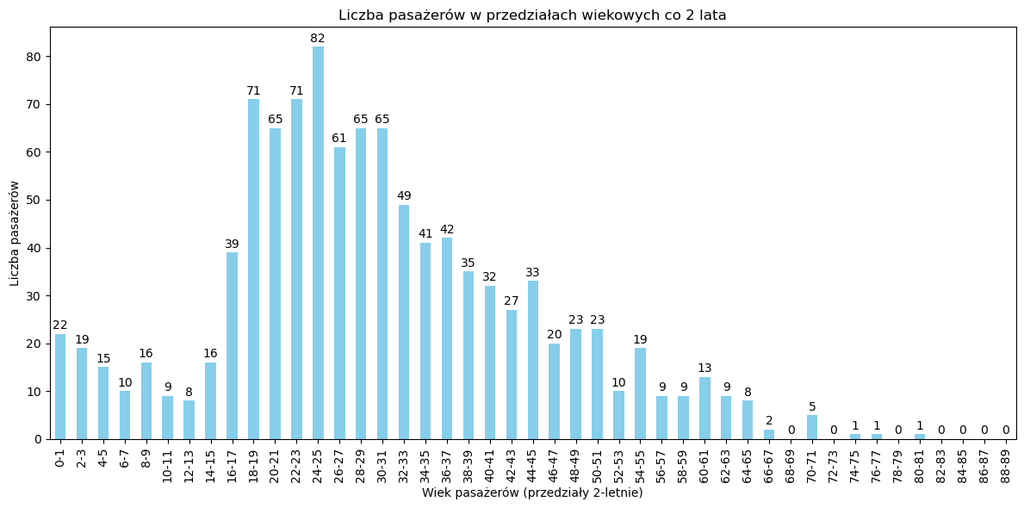

```python
df = df.dropna(subset=['Wiek'])

# Create age bins with a 2-year interval
bins = range(0, 92, 2)
labels = [f"{i}-{i+1}" for i in bins[:-1]]

# Cut the age data into bins
df['age_group'] = pd.cut(df['Wiek'], bins=bins, labels=labels, right=False)

# Count the number of passengers in each age group
age_group_counts = df['age_group'].value_counts().sort_index()

# Plotting
plt.figure(figsize=(12, 6))
age_group_counts.plot(kind='bar', color='skyblue')

# Add labels and title
plt.xlabel('Wiek pasażerów (przedziały 2-letnie)')
plt.ylabel('Liczba pasażerów')
plt.title('Liczba pasażerów w przedziałach wiekowych co 2 lata')

# Annotate the bars with the counts
for index, value in enumerate(age_group_counts):
    plt.text(index, value + 1, str(value), ha='center')

# Save the plot as a PNG file
plt.tight_layout()
plt.savefig("age_distribution.png")
```

Ten wykres przekrój wiekku pasażerów pozwala dość szczegółowo zobaczyc np:

1. Dominują wśród pasażerów 24-25latkowie.

A co z zestawieniem pasażerów którzy przeżyli i nie przeżyli wg ich wieku ?

[figure not shown]

```python
survived_passengers = df[df['Przeżył ?'] == 1]

# Drop NaN values in 'age' column
survived_passengers = survived_passengers.dropna(subset=['Wiek'])

# Create age bins with a range of 10 years
bins = range(0, 91, 10)
labels = [f"{i}-{i+9}" for i in bins[:-1]]

# Create a new column 'age_group' for age bins
survived_passengers['age_group'] = pd.cut(survived_passengers['Wiek'], bins=bins, labels=labels, right=False)

# Count the number of passengers in each age group
age_group_counts = survived_passengers['age_group'].value_counts().sort_index()

# Plotting
plt.figure(figsize=(10, 6))
age_group_counts.plot(kind='bar', color='skyblue')
plt.title('Liczba pasażerów, którzy przeżyli - wg grup wiekowych')
plt.xlabel('Grupa wiekowa')
plt.ylabel('Liczba pasażerów')

# Annotate the bars with the counts
for index, value in enumerate(age_group_counts):
    plt.text(index, value + 1, str(value), ha='center')

# Save the plot as a PNG file
plt.tight_layout()
plt.savefig("survived_passengers_age_group.png")
```

Osoby, które przeżyły katastrofę (wg wieku)

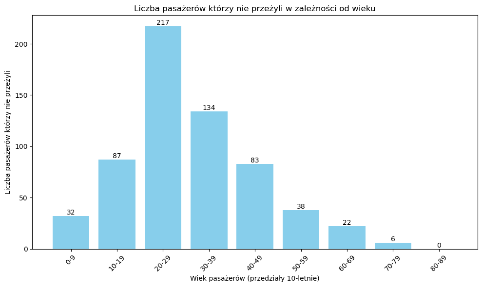

```python
non_survivors = df[df['Przeżył ?'] == 0]

# Drop NaN values in the 'age' column
non_survivors = non_survivors.dropna(subset=['Wiek'])

# Create age bins for every 10 years
age_bins = range(0, 91, 10)
age_labels = [f"{i}-{i+9}" for i in age_bins[:-1]]

# Bin the ages
non_survivors['age_group'] = pd.cut(non_survivors['Wiek'], bins=age_bins, labels=age_labels, right=False)

# Count the number of non-survivors in each age group
age_group_counts = non_survivors['age_group'].value_counts().sort_index()

# Plotting
plt.figure(figsize=(10, 6))
bars = plt.bar(age_group_counts.index, age_group_counts.values, color='skyblue')

# Add text annotations above the bars
for bar in bars:
    yval = bar.get_height()
    plt.text(bar.get_x() + bar.get_width()/2, yval, int(yval), va='bottom', ha='center')

plt.xlabel('Wiek pasażerów (przedziały 10-letnie)')
plt.ylabel('Liczba pasażerów którzy nie przeżyli')
plt.title('Liczba pasażerów którzy nie przeżyli w zależności od wieku')
plt.xticks(rotation=45)
plt.tight_layout()

# Save the plot as a PNG file
plt.savefig("non_survivors_age_distribution.png")
```

A teraz zestawienie osób, którzy nie przeżyli katastrofy. (wg wieku)

```python
Żeby lepiej zobaczyć stosunek tych co zginęli do tych uratowanych,
zestawmy dane razem.
```

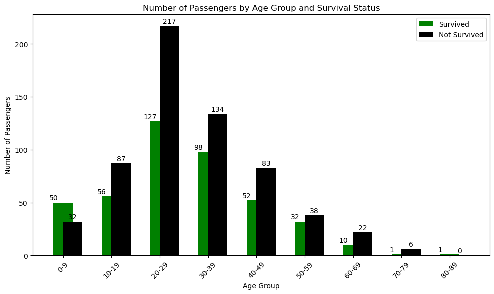

```python
df = df.dropna(subset=['Wiek'])

# Create bins for age groups
bins = range(0, 91, 10)
labels = [f"{i}-{i+9}" for i in bins[:-1]]

# Add a new column for age group
df['age_group'] = pd.cut(df['Wiek'], bins=bins, labels=labels, right=False)

# Separate data for those who survived and those who did not
survived = df[df['Przeżył ?'] == 1]
not_survived = df[df['Przeżył ?'] == 0]

# Count the number of passengers in each age group for both categories
survived_counts = survived['age_group'].value_counts().sort_index()
not_survived_counts = not_survived['age_group'].value_counts().sort_index()

# Plotting
plt.figure(figsize=(10, 6))

# Plot for survived passengers
plt.bar(survived_counts.index, survived_counts.values, width=0.4, label='Survived', color='green', align='center')

# Plot for not survived passengers
plt.bar(not_survived_counts.index, not_survived_counts.values, width=0.4, label='Not Survived', color='black', align='edge')

# Add labels above bars
for index, value in enumerate(survived_counts.values):
    plt.text(index - 0.2, value + 1, str(value), ha='center', va='bottom', color='black')

for index, value in enumerate(not_survived_counts.values):
    plt.text(index + 0.2, value + 1, str(value), ha='center', va='bottom', color='black')

# Customize the plot
plt.xlabel('Age Group')
plt.ylabel('Number of Passengers')
plt.title('Number of Passengers by Age Group and Survival Status')
plt.legend()
plt.xticks(rotation=45)

# Save the plot as a PNG file
plt.tight_layout()
plt.savefig("passenger_age_survival.png")
```

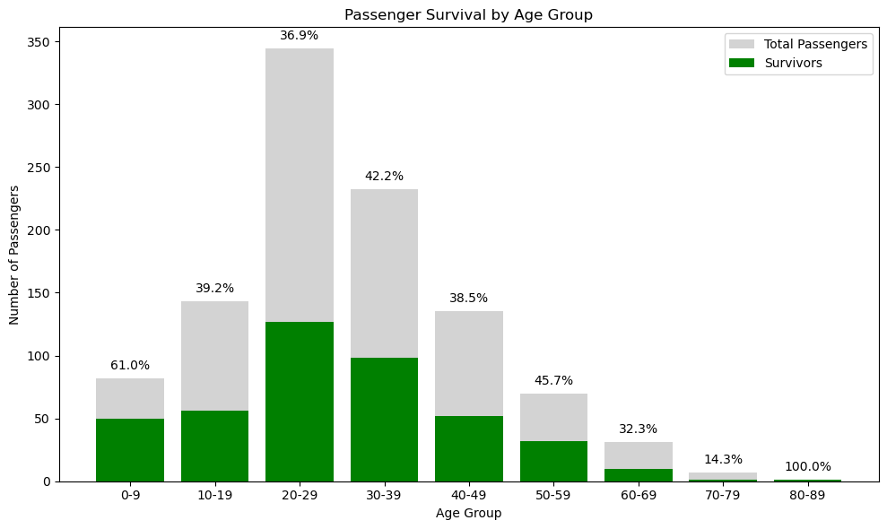

```python
df = df.dropna(subset=['Wiek'])

# Create age bins
bins = np.arange(0, 91, 10)
labels = [f'{i}-{i+9}' for i in bins[:-1]]

# Add a new column for age bins
df['age_group'] = pd.cut(df['Wiek'], bins=bins, labels=labels, right=False)

# Calculate total passengers and survivors in each age group
age_group_counts = df['age_group'].value_counts().sort_index()
survivors_by_age_group = df[df['Przeżył ?'] == 1]['age_group'].value_counts().sort_index()

# Calculate survival percentage
survival_percentage = (survivors_by_age_group / age_group_counts * 100).fillna(0)

# Plotting
fig, ax = plt.subplots(figsize=(10, 6))

# Plot total passengers
ax.bar(age_group_counts.index, age_group_counts.values, label='Total Passengers', color='lightgray')

# Plot survivors
ax.bar(survivors_by_age_group.index, survivors_by_age_group.values, label='Survivors', color='green')

# Annotate survival percentages
for i, (total, survived) in enumerate(zip(age_group_counts, survivors_by_age_group)):
    ax.text(i, total + 5, f'{survival_percentage[i]:.1f}%', ha='center', va='bottom', fontsize=10)

# Set labels and title
ax.set_xlabel('Age Group')
ax.set_ylabel('Number of Passengers')
ax.set_title('Passenger Survival by Age Group')
ax.legend()

# Save plot to a file
plt.tight_layout()
plt.savefig('age_group_survival.png')
```

% Wskaźnik przeżycia dla każdej z grup wiekowych.

1. Dzieci do lat 9 miały największy procent przeżycia. Możliwe, że dzieci były wpuszczane jako piewsze na łodzie ratunkowe. Czy były same ? Wątpię. Czy z naszych danch można wywnioskować kto z nimi był ? Jaka grupa wiekowa była ich rodzicami ? Czy może wchodziły na łódź razem z matkami a ojcowie zostawali na statku ?
2. Co ciekawe większy procent przeżycia katastrofy miała grupa 30-39 niż 10-19 lat. Czy wynika to stąd, że z tej właśnie grupy wiekowej pochodzili rodzice dzieci umieszczanych razem z nimi w łodziach ratunkowych ? Zobaczmy czy wykresy z podziałem na płeć osób które przeżyły to potwierdzą.

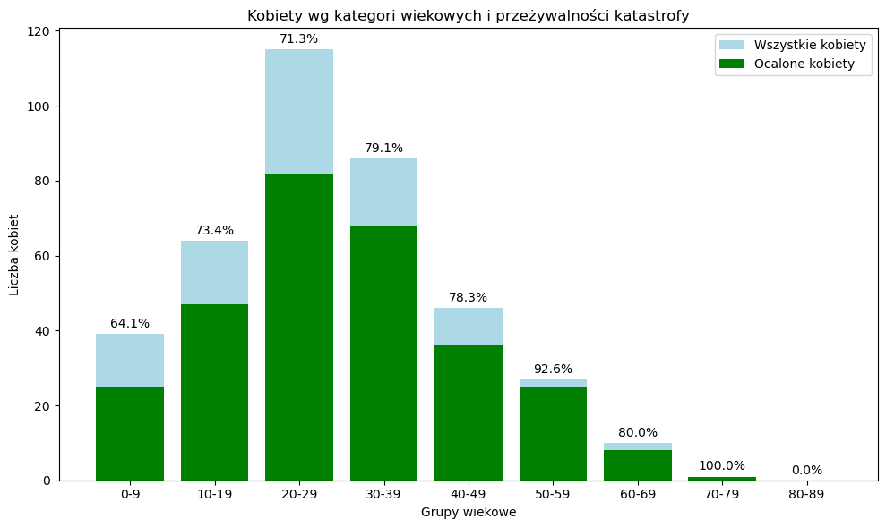

```python
female_passengers = df[df['Płeć'] == 'Kobieta']

# Drop rows with missing age values
female_passengers = female_passengers.dropna(subset=['Wiek'])

# Create age bins
bins = np.arange(0, 91, 10)
labels = [f"{i}-{i+9}" for i in bins[:-1]]

# Bin the ages
female_passengers['age_group'] = pd.cut(female_passengers['Wiek'], bins=bins, labels=labels, right=False)

# Calculate the number of females and those who survived in each age group
age_group_counts = female_passengers['age_group'].value_counts().sort_index()
survived_counts = female_passengers[female_passengers['Przeżył ?'] == 1]['age_group'].value_counts().sort_index()

# Calculate survival percentages
survival_percentages = (survived_counts / age_group_counts * 100).fillna(0)

# Plotting
fig, ax = plt.subplots(figsize=(10, 6))

# Plot total females
ax.bar(age_group_counts.index, age_group_counts, color='lightblue', label='Wszystkie kobiety')

# Plot survived females
ax.bar(survived_counts.index, survived_counts, color='green', label='Ocalone kobiety')

# Annotate survival percentages
for i, (count, percent) in enumerate(zip(age_group_counts, survival_percentages)):
    ax.text(i, count + 1, f'{percent:.1f}%', ha='center', va='bottom')

# Set labels and title
ax.set_xlabel('Grupy wiekowe')
ax.set_ylabel('Liczba kobiet')
ax.set_title('Kobiety wg kategori wiekowych i przeżywalności katastrofy')
ax.legend()

# Save plot to a file
plt.tight_layout()
plt.savefig("Female_survival_by_age.png")
```

Przeżywalność kobiet z katastrowy była duża. Najliczniejszą grupę stanowią tu kobiety z przedziału 30-39 oraz 20-29 i to pewnie w skład tych grup wchodzą matki, które mogły być umieszczane w pierwszej kolejności w łodziach ratunkowych. Patrząc na procent przeżywalności kobiet z grup starszych 50-59 można powiedzieć, że kobiety te były traktowane bardziej priorytetowo od matek czy dzieci.

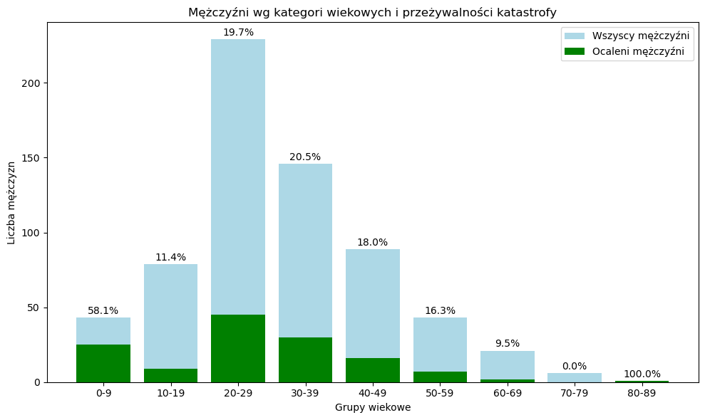

```python
male_passengers = df[df['Płeć'] == 'Mężczyzna']

# Drop rows with missing age values
male_passengers = male_passengers.dropna(subset=['Wiek'])

# Create age bins
bins = np.arange(0, 91, 10)
labels = [f"{i}-{i+9}" for i in bins[:-1]]

# Bin the ages
male_passengers['age_group'] = pd.cut(male_passengers['Wiek'], bins=bins, labels=labels, right=False)

# Calculate the number of females and those who survived in each age group
age_group_counts = male_passengers['age_group'].value_counts().sort_index()
survived_counts = male_passengers[male_passengers['Przeżył ?'] == 1]['age_group'].value_counts().sort_index()

# Calculate survival percentages
survival_percentages = (survived_counts / age_group_counts * 100).fillna(0)

# Plotting
fig, ax = plt.subplots(figsize=(10, 6))

# Plot total females
ax.bar(age_group_counts.index, age_group_counts, color='lightblue', label='Wszyscy mężczyźni')

# Plot survived females
ax.bar(survived_counts.index, survived_counts, color='green', label='Ocaleni mężczyźni')

# Annotate survival percentages
for i, (count, percent) in enumerate(zip(age_group_counts, survival_percentages)):
    ax.text(i, count + 1, f'{percent:.1f}%', ha='center', va='bottom')

# Set labels and title
ax.set_xlabel('Grupy wiekowe')
ax.set_ylabel('Liczba mężczyzn')
ax.set_title('Mężczyźni wg kategori wiekowych i przeżywalności katastrofy')
ax.legend()

# Save plot to a file
plt.tight_layout()
plt.savefig("Male_survival_by_age.png")
```

Przeżywalność mężczyzn z katastrowy była bardzo mała. Najliczniejszą grupę ocalałych stanowią tu mężczyźni z przedziału 20-29 oraz 30-39. Możemy jeszcze sprawdzić czy meżczyźni, którzy przeżyli byli spokrewnieni z kobietami, które przeżyły. To by świadczyło, że trzymali się razem z powodu związku czy pokrewieństwa.

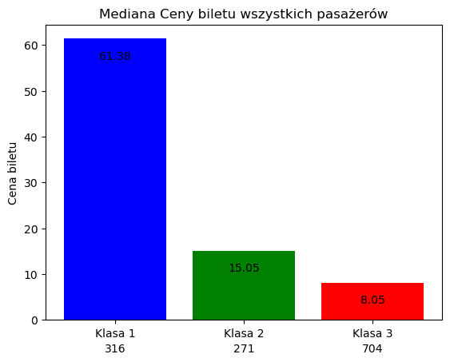

```python
filtered_df = df[(df['Cena biletu'] > 0) & (df['Cena biletu'].notna())]

# Calculate medians for each class
medians = filtered_df.groupby('Klasa biletu')['Cena biletu'].median()

# Count passengers in each class
passenger_counts = filtered_df['Klasa biletu'].value_counts().sort_index()

# Plotting
fig, ax = plt.subplots()
bars = ax.bar(medians.index, medians.values, color=['blue', 'green', 'red'])

# Add median values below each bar
for bar, median, count in zip(bars, medians, passenger_counts):
    ax.text(bar.get_x() + bar.get_width() / 2, bar.get_height() - 5, f'{median:.2f}', ha='center', va='bottom')
    ax.text(bar.get_x() + bar.get_width() / 2, -5, f'{count}', ha='center', va='top')

# Set labels and title
ax.set_ylabel('Cena biletu')
ax.set_title('Mediana Ceny biletu wszystkich pasażerów')
ax.set_xticks(medians.index)
ax.set_xticklabels(['Klasa 1', 'Klasa 2', 'Klasa 3'])


# Save plot as a PNG file
plt.savefig('median_fare_by_class.png')
```

Widzimy zaskakująco duże różnice w cenie biletu drugiej i pierwszej klasy, no i oczywiście trzeciej i pierwszej. Ciekawe, co wpływało na tak dużą różnicę cen między pierwszą i drugą klasą. Może dalsza analiza danych coś wykaże.

Jakie były najtańsze i najdroższe bilety w danej klasie ?

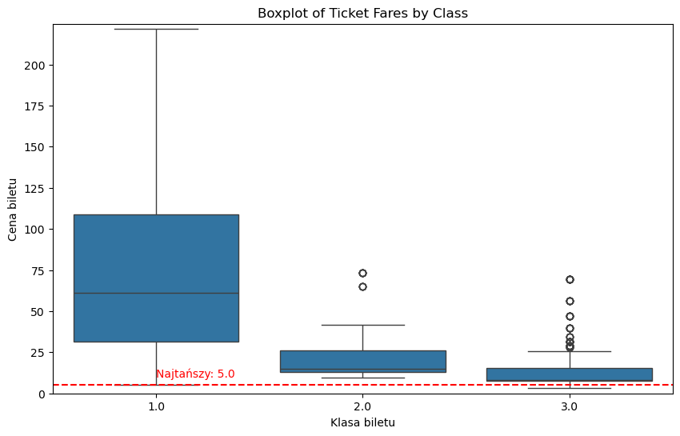

```python
# Remove NaN values and filter out zero fares
df = df.dropna(subset=['Cena biletu', 'Klasa biletu'])
df = df[df['Cena biletu'] > 0]

# Calculate the interquartile range (IQR) for each class to identify outliers
def calculate_iqr_limits(data):
    Q1 = data.quantile(0.25)
    Q3 = data.quantile(0.75)
    IQR = Q3 - Q1
    lower_bound = Q1 - 1.5 * IQR
    upper_bound = Q3 + 1.5 * IQR
    return lower_bound, upper_bound

# Get the upper limit for each class
upper_limits = {}
for pclass in df['Klasa biletu'].unique():
    class_fares = df[df['Klasa biletu'] == pclass]['Cena biletu']
    _, upper_limit = calculate_iqr_limits(class_fares)
    upper_limits[pclass] = upper_limit

# Create a boxplot
plt.figure(figsize=(10, 6))
sns.boxplot(x='Klasa biletu', y='Cena biletu', data=df)

# Add a line for the cheapest ticket in first class
cheapest_first_class_fare = df[df['Klasa biletu'] == 1]['Cena biletu'].min()
plt.axhline(y=cheapest_first_class_fare, color='r', linestyle='--')
plt.text(0, cheapest_first_class_fare + 5, f'Najtańszy: {cheapest_first_class_fare}', color='r')

# Set y-axis limit to the maximum non-outlier fare
max_non_outlier_fare = max(upper_limits.values())
plt.ylim(0, max_non_outlier_fare)

plt.title('Boxplot of Ticket Fares by Class')
plt.xlabel('Klasa biletu')
plt.ylabel('Cena biletu')

# Save the plot as a PNG file
plt.savefig('boxplot_fares.png')
```

Zastanawia pokrywanie się części cen biletów klasy pierwszej z drugą i trzecią. Trudno uwierzyć że w cenie 25 można było mieć bilet 1 klasy. Czy to może być błąd spisu czy błąd bazy danych ?

A jak wyglądała liczba spokrewnionych osób na statku przez małżonka, dziecko lub rodziców ?

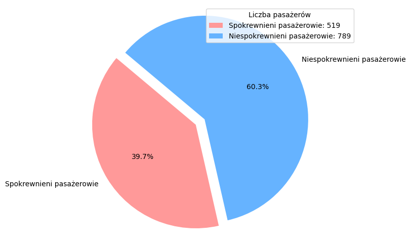

```python
related_passengers = df[(df['Ilość-rodzeństwo/małżonek'] > 0) | (df['Ilość-rodziców/dzieci'] > 0)].shape[0]
unrelated_passengers = df[(df['Ilość-rodzeństwo/małżonek'] == 0) & (df['Ilość-rodziców/dzieci'] == 0)].shape[0]

# Prepare data for the pie chart
labels = ['Spokrewnieni pasażerowie', 'Niespokrewnieni pasażerowie']
sizes = [related_passengers, unrelated_passengers]
colors = ['#ff9999','#66b3ff']
explode = (0.1, 0)  # explode the first slice

# Plotting the pie chart
plt.figure(figsize=(8, 6))
plt.pie(sizes, explode=explode, labels=labels, colors=colors, autopct='%1.1f%%', startangle=140)
plt.axis('equal')  # Equal aspect ratio ensures that pie is drawn as a circle.

# Add legend with numbers
plt.legend(title="Liczba pasażerów", loc="upper right", labels=[
    f'Spokrewnieni pasażerowie: {related_passengers}',
    f'Niespokrewnieni pasażerowie: {unrelated_passengers}'
])

# Save the plot as a PNG file
plt.savefig("passenger_distribution.png")
```

A co z pasażerami którzy przeżyli ? Ile z nich było spokrewnionych ze sobą ? 39,7% pasażerów była spokrewniona ze sobą. Wydaje się to bardzo dużym procentem, który przedstawia rejs Tytanikiem jako wyprawę rodzinną czy to w poszukiwaniu lepszych warunków życia w Ameryce, czy też jako wycieczkę, lub jako podróż w odwiedzinach. Ciekawe, czy można by było jakoś obliczyć ile z tych osób odbywało tą podróż w poszukiwaniu lepszego życia ? Nasuwa się przypuszczenie, że musieli należeć do klasy mniej zamożnej, której nie było stać na kupno biletów pierwszej klasy. Sprawdźmy zatem ile osób spokrewnionych kupiło bilety 3 i 2 klasy.

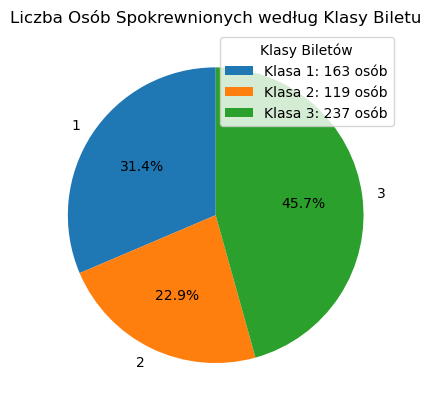

```python
# Calculate the number of related people who bought tickets for each class
related_people = df[(df['Ilość-rodzeństwo/małżonek'] > 0) | (df['Ilość-rodziców/dzieci'] > 0)]
ticket_counts_related = related_people['Klasa biletu'].value_counts().sort_index()

# Plotting
fig, ax = plt.subplots()
ticket_counts_related.plot(kind='pie', autopct='%1.1f%%', startangle=90, ax=ax)
ax.set_ylabel('')
ax.set_title('Liczba Osób Spokrewnionych według Klasy Biletu')

# Add legend with ticket numbers
legend_labels = [f'Klasa {int(index)}: {count} osób' for index, count in ticket_counts_related.items()]
ax.legend(legend_labels, title="Klasy Biletów", loc="upper right")

# Save the plot as a PNG file
plt.savefig("related_ticket_distribution.png")
```

Jak widzimy najwięcej osób spokrewnionych kupowało bilety 3 klasy. To by potwierdzało hipotezę, że rodziny podróżowały w celu poszukiwania lepszego życia w Ameryce. Sprawdzając domenę danych, natrafiłem na obliczenia emigrantów z Europy do Ameryki w latach 1900-1920, i właśnie rok 1912 był rekordowy z liczbą 1 800 000 emigranów.

A jakie bylety kupowały osoby niespokrewnione ? Czy był wśród nich duży odsetek emigrantów ? Wykres poniżej raczej to potwierdza.

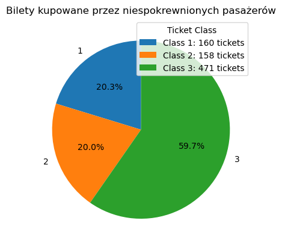

```python
# Calculate the number of non-related people who bought tickets for each class
non_related = df[(df['Ilość-rodzeństwo/małżonek'] == 0) & (df['Ilość-rodziców/dzieci'] == 0)]
ticket_counts = non_related['Klasa biletu'].value_counts().sort_index()

# Plotting
fig, ax = plt.subplots()
ticket_counts.plot(kind='pie', autopct='%1.1f%%', startangle=90, ax=ax)
ax.set_ylabel('')
ax.set_title('Bilety kupowane przez niespokrewnionych pasażerów')

# Adding legend with ticket numbers
legend_labels = [f"Class {int(index)}: {count} tickets" for index, count in ticket_counts.items()]
ax.legend(legend_labels, title="Ticket Class", loc="upper right")

# Save the plot as a PNG file
plt.savefig("ticket_class_distribution.png")
```

Jak widzimy osób niespokrewnionch też najwięcej było z trzeciej klasy. Zestawiając to z ogólnym podziałem kupionych biletów na statku nie dziwi ten wynik. Możemy jednak po tych wykresach trochę wyszczególnić danych:

- Wśród pasażerów 3 klasy - 471 osób było niespokrewnionych, a 237 było spokrewnione
- Wśród pasażerów 2 klasy - 158 osób było niespokrewnionych, a 119 było spokrewnione
- Wśród pasażerów 1 klasy - 160 osób było niespokrewnionych, a 163 było spokrewnione
- Wg wartości procentowej to najwięcej osób spokrewnionych znajdziemy w 1 klasie.

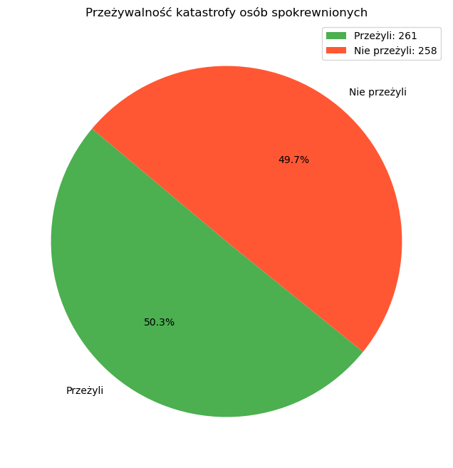

```python
df['Przeżył ?'] = df['Przeżył ?'].replace({'Tak':1, 'Nie':0})
# Treba było zamienić z powrotem wartości typu str na liczbowe
related_people = df[(df['Ilość-rodzeństwo/małżonek'] > 0) | (df['Ilość-rodziców/dzieci'] > 0)]
survived_related = related_people[related_people['Przeżył ?'] == 1].shape[0]
not_survived_related = related_people[related_people['Przeżył ?'] == 0].shape[0]

# Calculate percentages
total_related = survived_related + not_survived_related
survived_percentage = (survived_related / total_related) * 100
not_survived_percentage = (not_survived_related / total_related) * 100

# Plotting
labels = ['Przeżyli', 'Nie przeżyli']
sizes = [survived_related, not_survived_related]
colors = ['#4CAF50', '#FF5733']

plt.figure(figsize=(8, 8))
plt.pie(sizes, labels=labels, colors=colors, autopct='%1.1f%%', startangle=140)
plt.title('Przeżywalność katastrofy osób spokrewnionych')

# Add legend with numbers
plt.legend([f'Przeżyli: {survived_related}', f'Nie przeżyli: {not_survived_related}'], loc='upper right')

# Save the plot
plt.savefig('survival_chart.png')
```

Przeżywalność osób spokrewnionych była koło 50% Czy jest to duży procent ? Sprawdźmy jeszcze przeżywalność osób niespokrewnionch, żeby wyrobić sobie jakąś opinię.

[figure not shown]

```python
# Calculate the number of unrelated people (sibsp + parch == 0)
unrelated_people = df[(df['Ilość-rodzeństwo/małżonek'] == 0) & (df['Ilość-rodziców/dzieci'] == 0)]

# Calculate the number of unrelated people who survived and did not survive
unrelated_survived = unrelated_people[unrelated_people['Przeżył ?'] == 1].shape[0]
unrelated_not_survived = unrelated_people[unrelated_people['Przeżył ?'] == 0].shape[0]

# Calculate percentages
total_unrelated = unrelated_survived + unrelated_not_survived
percent_survived = (unrelated_survived / total_unrelated) * 100
percent_not_survived = (unrelated_not_survived / total_unrelated) * 100

# Plotting
labels = ['Przeżyli', 'Nie przeżyli']
sizes = [percent_survived, percent_not_survived]
colors = ['#4CAF50', '#FF5733']

plt.figure(figsize=(8, 6))
plt.pie(sizes, labels=labels, colors=colors, autopct='%1.1f%%', startangle=140)
plt.title('Przeżywalność katastrofy osób niespokrewnionych')

# Add legend with counts
plt.legend([f'Przeżyli: {unrelated_survived}', f'Nie przeżyli: {unrelated_not_survived}'], loc='upper right')

# Save the plot
plt.savefig('unrelated_survival_chart.png')
```

Osoby spokrewnione miały dużą większą szansę przeżycia od niespokrewnionych. Z czego może to wynikać ?

A co z korelacjami naszych danych ?

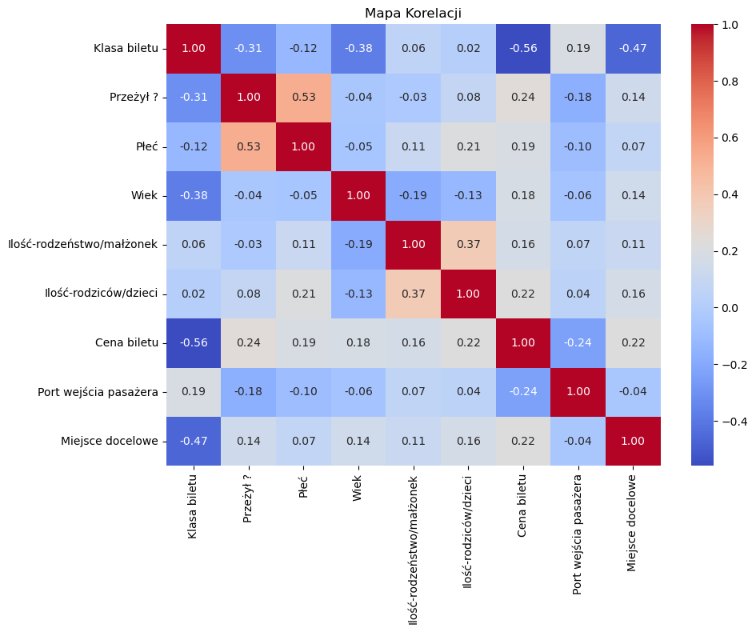

```python
# Wybierz odpowiednie kolumny
columns_of_interest = ['Klasa biletu', 'Przeżył ?', 'Płeć', 'Wiek', 'Ilość-rodzeństwo/małżonek', 'Ilość-rodziców/dzieci', 'Cena biletu', 'Port wejścia pasażera', 'Miejsce docelowe']

# Obsługa brakujących wartości i kodowanie zmiennych kategorycznych
df_selected = df[columns_of_interest].copy()

# Wypełnij brakujące wartości odpowiednimi strategiami
df_selected['Wiek'].fillna(df_selected['Wiek'].median(), inplace=True)
df_selected['Cena biletu'].fillna(df_selected['Cena biletu'].median(), inplace=True)
df_selected['Klasa biletu'].fillna(df_selected['Klasa biletu'].mode()[0], inplace=True)
df_selected['Przeżył ?'].fillna(df_selected['Przeżył ?'].mode()[0], inplace=True)
df_selected['Ilość-rodzeństwo/małżonek'].fillna(df_selected['Ilość-rodzeństwo/małżonek'].mode()[0], inplace=True)
df_selected['Ilość-rodziców/dzieci'].fillna(df_selected['Ilość-rodziców/dzieci'].mode()[0], inplace=True)

# Zakoduj zmienne kategoryczne
df_selected['Płeć'] = df_selected['Płeć'].map({'Mężczyzna': 0, 'Kobieta': 1})
df_selected['Port wejścia pasażera'] = df_selected['Port wejścia pasażera'].map({'C': 0, 'Q': 1, 'S': 2})
df_selected['Miejsce docelowe'] = df_selected['Miejsce docelowe'].astype('category').cat.codes

# Przekształć kolumnę "Przeżył" na typ numeryczny
df_selected['Przeżył ?'] = df_selected['Przeżył ?'].map({'Tak': 1, 'Nie': 0})

# Oblicz macierz korelacji
correlation_matrix = df_selected.corr()

# Wyświetl mapę korelacji
plt.figure(figsize=(10, 8))
sns.heatmap(correlation_matrix, annot=True, cmap='coolwarm', fmt=".2f")
plt.title('Mapa Korelacji')
plt.tight_layout()

# Zapisz wykres jako plik PNG
plt.savefig('correlation_map.png')
```

Korelacja między "Wiek" a "Przeżył?" jest bardzo słaba, co sugeruje, że wiek nie miał znaczącego wpływu na przeżycie podczas katastrofy Titanica. Inne czynniki, takie jak "Płeć" i "Klasa biletu", miały większe znaczenie.

Korelacja między "Ilość rodzeństwo/małżonek" a "Przeżył?" jest bardzo słaba, co sugeruje, że liczba rodzeństwa/małżonków na pokładzie nie miała znaczącego wpływu na przeżycie podczas katastrofy Titanica.

Korelacja między "Ilość-rodziców/dzieci" a "Przeżył?" jest bardzo słaba, co sugeruje, że liczba rodziców/dzieci na pokładzie miała nieznaczny wpływ na przeżycie podczas katastrofy Titanica

Wyniki sugerują, że klasa biletu była ważnym czynnikiem wpływającym na przeżywalność na Titanicu. Prawdopodobnie wynikało to z tego, że pasażerowie w niższych klasach mieli mniejszy dostęp do szalup ratunkowych.

Cena biletu również miała wpływ na przeżywalność, co może sugerować, że osoby, które płaciły więcej za bilety, miały dostęp do lepszych miejsc w statku lub do innych udogodnień, które zwiększyły ich szanse na przeżycie.

1. Iloraz szans (Odds Ratio) Definicja: Iloraz szans to stosunek prawdopodobieństwa wystąpienia zdarzenia do prawdopodobieństwa jego braku. W kontekście regresji logistycznej, iloraz szans dla danej zmiennej niezależnej pokazuje, jak zmiana tej zmiennej wpływa na prawdopodobieństwo wystąpienia zdarzenia (np. przeżycia). Interpretacja: Jeśli iloraz szans wynosi 1, nie ma wpływu na prawdopodobieństwo. Jeśli iloraz szans jest większy niż 1, wzrost zmiennej zwiększa prawdopodobieństwo zdarzenia. Jeśli iloraz szans jest mniejszy niż 1, wzrost zmiennej zmniejsza prawdopodobieństwo zdarzenia.
2. Współczynniki regresji Wartości współczynników: Współczynniki w modelu regresji logistycznej pokazują, jak zmiana jednostkowa w zmiennej niezależnej wpływa na logarytm ilorazu szans. Interpretacja: Dodatni współczynnik oznacza, że wzrost zmiennej niezależnej zwiększa prawdopodobieństwo wystąpienia zdarzenia. Ujemny współczynnik oznacza, że wzrost zmiennej niezależnej zmniejsza prawdopodobieństwo wystąpienia zdarzenia.
3. Wartości p (P>|z|) Znaczenie: Wartości p informują o istotności statystycznej współczynników. Interpretacja: Wartość p mniejsza niż 0.05 sugeruje, że współczynnik jest istotny statystycznie, co oznacza, że zmienna ma znaczący wpływ na prawdopodobieństwo zdarzenia. Wartości p większe niż 0.05 sugerują, że zmienna nie ma istotnego wpływu.
4. Pseudo R-kwadrat Definicja: Pseudo R-kwadrat to miara, która wskazuje, jak dobrze model dopasowuje się do danych. Interpretacja: Wartości bliskie 1 sugerują dobre dopasowanie modelu, podczas gdy wartości bliskie 0 wskazują na słabe dopasowanie.
5. Wizualizacja wyników Wizualizacje: Warto również wizualizować wyniki, aby lepiej zrozumieć wpływ poszczególnych zmiennych na prawdopodobieństwo zdarzenia. Możesz użyć wykresów ilustrujących iloraz szans lub wykresów wpływu zmiennych. Przykład interpretacji W Twoim modelu:

### Analiza wartości odstających.

Nie dla każdej kolumny ze względu na typ danych warto robić boxplot. Chociażby dlatego, że w wielu kolumnach nie będzie danych odstających lub ich określenie będzie niemożliwe ze względu na typ danych.

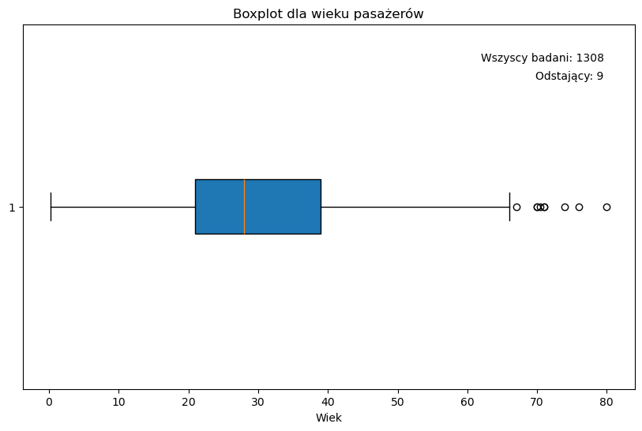

```python
# Drop NaN values from the 'age' column for accurate plotting
age_data = df['Wiek'].dropna()

# Calculate outliers
Q1 = age_data.quantile(0.25)
Q3 = age_data.quantile(0.75)
IQR = Q3 - Q1
outliers = age_data[(age_data < (Q1 - 1.5 * IQR)) | (age_data > (Q3 + 1.5 * IQR))]

# Create the boxplot
plt.figure(figsize=(10, 6))
plt.boxplot(age_data, vert=False, patch_artist=True)

# Annotate the plot with the number of outliers and total values
plt.annotate(f'Wszyscy badani: {len(sibsp_data)}', xy=(0.95, 0.9), xycoords='axes fraction', fontsize=10, ha='right')
plt.annotate(f'Odstający: {len(outliers)}', xy=(0.95, 0.85), xycoords='axes fraction', fontsize=10, ha='right')

# Add title and labels
plt.title('Boxplot dla wieku pasażerów')
plt.xlabel('Wiek')

# Save the plot as a PNG file
plt.savefig('age_boxplot.png')
```

Połowa pasażerów to osoboy w przedziale ok 20-40 lat. 25% stanowią osboby do 20 roku oraz osoby ok 40-65lat. Wartości odstające to osoby po ok. 66 roku życia.

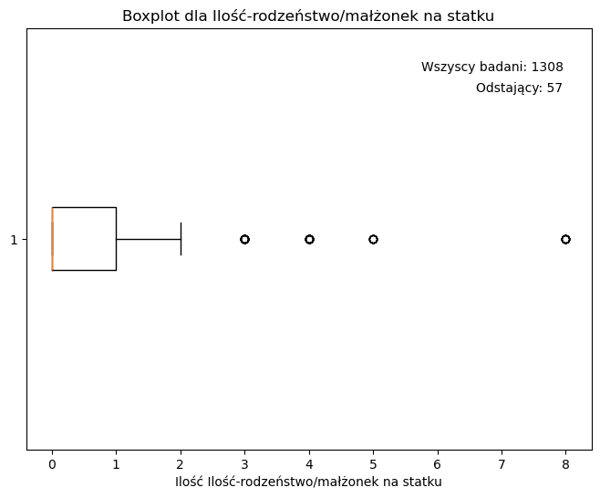

```python
# Drop NaN values from the 'sibsp' column
sibsp_data = df['Ilość-rodzeństwo/małżonek'].dropna()

# Calculate the quartiles and IQR
Q1 = sibsp_data.quantile(0.25)
Q3 = sibsp_data.quantile(0.75)
IQR = Q3 - Q1

# Determine outliers
outliers = sibsp_data[(sibsp_data < (Q1 - 1.5 * IQR)) | (sibsp_data > (Q3 + 1.5 * IQR))]

# Create the boxplot
plt.figure(figsize=(8, 6))
plt.boxplot(sibsp_data, vert=False)
plt.title('Boxplot dla Ilość-rodzeństwo/małżonek na statku')
plt.xlabel('Ilość Ilość-rodzeństwo/małżonek na statku')

# Annotate the plot with the number of outliers and total values
plt.annotate(f'Wszyscy badani: {len(sibsp_data)}', xy=(0.95, 0.9), xycoords='axes fraction', fontsize=10, ha='right')
plt.annotate(f'Odstający: {len(outliers)}', xy=(0.95, 0.85), xycoords='axes fraction', fontsize=10, ha='right')

# Save the plot as a PNG file
plt.savefig('sibsp_boxplot.png')
```

Na tym przykładzie widać, że kolumnę Ilość-rodzeństwo/małżonek warto by rozdzielić na dwie - Ilość rodzeństwo i drugą - Ilość małżonek. Kiedy te dane są zebrane razem wymagały by innego podejścia do ich interpretacji. Np można by zrobić boxpolt dla wartości powyżej jednego, co by znaczyło dane dotyczące ilość rodzeństwo, oprócz tych pasażerów, którzy mieli tylko jedno rodzeństwo.

A jakby zastosować inny rodzaj wizualizacji ? Przyjżyjmy się czy w takiej kolumnie, z zmieszanymi dwoma rodzajami danych (ilość rodzeństwo) oraz (iloość małożonek) inny rodzaj wizualizacji da wartościowszy wykres.

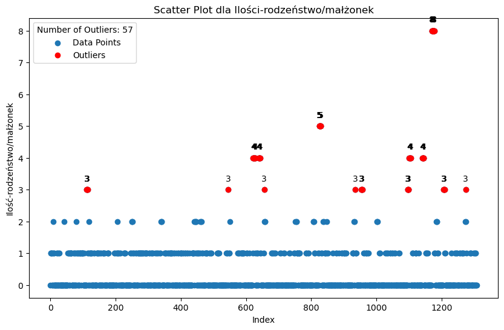

```python
# Calculate the IQR for the 'sibsp' column to identify outliers
Q1 = df['Ilość-rodzeństwo/małżonek'].quantile(0.25)
Q3 = df['Ilość-rodzeństwo/małżonek'].quantile(0.75)
IQR = Q3 - Q1

# Define the bounds for outliers
lower_bound = Q1 - 1.5 * IQR
upper_bound = Q3 + 1.5 * IQR

# Identify outliers
outliers = df[(df['Ilość-rodzeństwo/małżonek'] < lower_bound) | (df['Ilość-rodzeństwo/małżonek'] > upper_bound)]

# Create a scatter plot
plt.figure(figsize=(10, 6))
plt.scatter(df.index, df['Ilość-rodzeństwo/małżonek'], label='Data Points')
plt.scatter(outliers.index, outliers['Ilość-rodzeństwo/małżonek'], color='red', label='Outliers')

# Annotate the number of outliers on the plot
for i, row in outliers.iterrows():
    plt.annotate(f"{int(row['Ilość-rodzeństwo/małżonek'])}", (i, row['Ilość-rodzeństwo/małżonek']), textcoords="offset points", xytext=(0,10), ha='center')

# Add labels and title
plt.xlabel('Index')
plt.ylabel('Ilość-rodzeństwo/małżonek')
plt.title('Scatter Plot dla Ilości-rodzeństwo/małżonek')

# Add legend with the number of outliers
plt.legend(title=f"Number of Outliers: {len(outliers)}")

# Save the plot as a PNG file
plt.savefig("sibsp_outliers.png")
```

Na wykresie typu scatter plot lepiej widzimy rozkład wszystkich wartości, choć nie zmienia to że ilość rodzeństwa 3, mogła nie być traktowana jako wartość odstająca gdybyśmy mogli kolumnę (Ilość-rodzeństwo/małżonek) rozdzielić na dwie osobne kolumny z innym zakresem danych.

Sprawdźmy zatem inny rodzaj wykresu wartości odstających na bardziej reprezentatywnym zbiorze danych np. z kolumny (cena biletu).

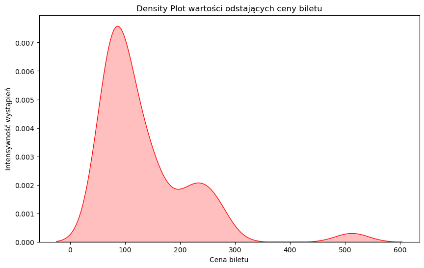

```python
# Calculate the IQR for the 'fare' column to identify outliers
Q1 = df['Cena biletu'].quantile(0.25)
Q3 = df['Cena biletu'].quantile(0.75)
IQR = Q3 - Q1

# Define outliers as values outside 1.5 * IQR from Q1 and Q3
outliers = df[(df['Cena biletu'] < (Q1 - 1.5 * IQR)) | (df['Cena biletu'] > (Q3 + 1.5 * IQR))]['Cena biletu']
# RB
# Plot the density plot for outliers
plt.figure(figsize=(10, 6))
sns.kdeplot(outliers, fill=True, color='r')
plt.title('Density Plot wartości odstających ceny biletu')
plt.xlabel('Cena biletu')
plt.ylabel('Intensywność wystąpień')

# Save the plot as a PNG file
plt.savefig('density_plot_outliers_fare.png')
```

Intensywność wystąpień ceny biletu osiąga największą ilość przy cenie 100. Spore zakresy są między 50 a 150 za bilet. Wartościami odstającymi mogą być tutaj wartości między 450 a 600 dla najdroższych biletów.